# CANTO - preprocessing

Mai 13, 2021

Correction des erreurs, equipe de Dijon

```r
l = c("01-00804" = "15/11/2012","01-04576" = "14/05/2014","01-06521" = "17/02/2015","01-09201" = "31/05/2016","03-03207" = "13/10/2013","03-03668" = "24/12/2013","03-03688" = "24/12/2013","03-05214" = "13/08/2014","03-06390" = "31/10/2014","06-06064" = "04/12/2014","06-06945" = "05/01/2015","06-08560" = "09/02/2016","06-08837" = "24/03/2016","07-00148" = "14/05/2012","07-00774" = "15/09/2012","07-01402" = "14/09/2012","07-02768" = "29/11/2012","07-06661" = "22/01/2015","07-07170" = "25/03/2015","08-04172" = "24/02/2014","09-03735" = "03/10/2013","10-00676" = "13/09/2012","10-04212" = "19/02/2014","10-04599" = "09/04/2014","10-06792" = "06/02/2015","10-07176" = "20/05/2015","10-08705" = "11/02/2016","10-09294" = "11/03/2016","11-02872" = "16/09/2013","13-00784" = "01/01/2012","13-02946" = "10/05/2013","13-09279" = "15/03/2016","14-00950" = "18/10/2012","14-02207" = "04/06/2013","14-06122" = "19/11/2014","14-08200" = "23/11/2015")

for(i in 1:length(l)){
  v = which(data.workBI$SUBJID == names(l)[i])
  data.workBI$DTDIAG[v] = as.character(l[i])
}


data.workBI$DTGANGLS_D[which(data.workBI$SUBJID=="07-01550" & data.workBI$DTGANGLS_D=="28/03/3013")] = "28/03/2013"
data.workBI$DTBILANHEMATO_BI[which(data.workBI$SUBJID=="16-07457" & data.workBI$DTBILANHEMATO_BI=="09/07/0201")] = "09/07/2001"
data.workBI$DTBILANOVAR_BI[which(data.workBI$SUBJID=="02-03470" & data.workBI$DTBILANOVAR_BI=="08/01/0214")] = "08/01/2014"
data.workBI$DTBILANRENAL_BI[which(data.workBI$SUBJID=="16-06848" & data.workBI$DTBILANRENAL_BI=="07/04/0201")] ="07/04/2001"
data.workBI$DTDEBFACTCROISS_ADJ[which(data.workBI$SUBJID=="02-02565" & data.workBI$DTDEBFACTCROISS_ADJ=="NK/112013")] = "NK/11/2013"
data.workBI$DTDEBHORM1[which(data.workBI$SUBJID=="01-08595" & data.workBI$DTDEBHORM1=="31/11/2016")] = "30/11/2016";
data.workBI$DTDEBHORM3[which(data.workBI$SUBJID=="05-03696" & data.workBI$DTDEBHORM3=="31/04/2018")] = "30/04/2018"
data.workBI$DTFEVG_BI[which(data.workBI$SUBJID=="06-08603" & data.workBI$DTFEVG_BI=="25/02/1016")] = "25/02/2016"
data.workBI$DTFINFACTCROISS_ADJ[which(data.workBI$SUBJID=="03-01851" & data.workBI$DTFINFACTCROISS_ADJ=="2511/2013")] = "25/11/2013"
data.workBI$DTFINHORM2[which(data.workBI$SUBJID=="05-03696" & data.workBI$DTFINHORM2=="31/04/2018")] = "30/04/2018"
data.workBI$DTFINHORM2[which(data.workBI$SUBJID=="07-00085" & data.workBI$DTFINHORM2=="DECES")] = "17/12/2017"
data.workBI$DTFINHORM2[which(data.workBI$SUBJID=="07-07541" & data.workBI$DTFINHORM2=="31/04/2017")] = "30/04/2017"
data.workBI$DTSIGN[which(data.workBI$SUBJID=="07-09381" & data.workBI$DTSIGN=="12/08/0216")] = "12/08/2016"


data.workBI$LOC[which(data.workBI$SUBJID=="07-00762")] = 2
data.workBI$LOC[which(data.workBI$SUBJID=="14-00196")] = 2
data.workBI$LOC[which(data.workBI$SUBJID=="17-03501")] = 2
data.workBI$LOC[which(data.workBI$SUBJID=="20-03280")] = 3


# 2.9 Autres corrections
data.workBI$SEQCHIMIO_ADJ[which(data.workBI$SUBJID=="09-06326")] = 1
data.workBI$SEQCHIMIO_ADJ[which(data.workBI$SUBJID=="09-08282")] = 2
data.workBI$DROGUE5_ADJ[which(data.workBI$SUBJID=="01-01201")] = ''

# taille
data.workBI$TAILLE[which(data.workBI$SUBJID=='16-06901')] = 160
data.workBI$TAILLE[which(data.workBI$SUBJID=='16-07261')] = 170
```

The original dataset in BI contains 9752 samples and 1013 columns.

# Clinical variables

## Bilateral

```r
data.workBI$bilat <- factor(NA, levels = c("no","yes"))
data.workBI$bilat[which(data.workBI$LOC %in% c("1","2"))] <- "no"
data.workBI$bilat[which(data.workBI$LOC %in% c("3"))] <- "yes"
data.workBI$bilat <- addNA(data.workBI$bilat)
table(data.workBI$bilat)
```

```
##
##   no  yes <NA>
## 9513  228   11
```

We remove 228 bilateral cases and 11 NAs

```r
###REMOVE BILATERAL
nobilat = which(data.workBI$bilat=="no")
data.workBI = data.workBI %>% filter(bilat=="no")
data.workBI$side <- unlist(lapply(data.workBI$LOC, function(x){if(x==1) "L" else "R"}))
table(data.workBI$side)
```

```
##
##    L    R
## 4857 4656
```

We obtain 9513 samples.

## Bifocal

```r
data.workBI$bifocal <- factor(NA, levels = c("no","yes"))
data.workBI$bifocal[which(data.workBI$LOC %in% c("1") & data.workBI$FORME_G %in% c("1"))] <- "no"
data.workBI$bifocal[which(data.workBI$LOC %in% c("1") & data.workBI$FORME_G %in% c("2"))] <- "yes"
data.workBI$bifocal[which(data.workBI$LOC %in% c("2") & data.workBI$FORME_D %in% c("1"))] <- "no"
data.workBI$bifocal[which(data.workBI$LOC %in% c("2") & data.workBI$FORME_D %in% c("2"))] <- "yes"
table(data.workBI$bifocal)
```

```
##
##   no  yes
## 7516  887
```

We keep bifocal patients.

```r
imputeDate = function(data, variable){
  v = c()
  new_var_name = paste0(variable, '_raw')
  data[, new_var_name] = NA
  data[, new_var_name] = data[,variable]

  vec = c(grep("ND",data[,variable]), grep("NK",data[,variable]), grep("NA/",data[,variable]))
  look = which(!vec %in%  c(grep("NKNKNK",data[,variable]), grep("ND/ND",data[,variable]), grep("NK/NK",data[,variable]),grep("NA/NA",data[,variable])))
  vec = vec[look]
  data[vec,variable] =  paste("15/",substr(data[vec,variable],4,10),sep="")

  data[, paste0(variable, '_IMPUTED_DAY')] = rep(0, nrow(data))
  data[vec, paste0(variable, '_IMPUTED_DAY')] = 1

   v = vec

  vec = c(grep("ND/ND",data[,variable]), grep("NK/NK",data[,variable]),grep("NA/NA",data[,variable]))
  data[vec,variable] =  paste("15/07/",substr(data[vec,variable],7,10),sep="")

  data[, paste0(variable, '_IMPUTED_DAY_MONTH')] = rep(0, nrow(data))
  data[vec, paste0(variable, '_IMPUTED_DAY_MONTH')] = 1

  v = c(v, vec)

  data[, paste0(variable, '_IMPUTED')] = rep(0, nrow(data))
  data[v, paste0(variable, '_IMPUTED')] = 1

  return(data)
}
```

## Date of diagnosis

```r
vec = c(grep("ND",data.workBI$DTDIAG), grep("NK",data.workBI$DTDIAG), grep("NA/",data.workBI$DTDIAG))
look = which(!vec %in%  c(grep("NKNKNK",data.workBI$DTDIAG), grep("ND/ND",data.workBI$DTDIAG), grep("NK/NK",data.workBI$DTDIAG),grep("NA/NA",data.workBI$DTDIAG)))
vec = vec[look]
length(vec)
```

```
## [1] 410
```

We have 410 patients with dates as NK/mm/yyyy.

We set for them the diagnosis at 15 of the month. We still have dates like:

```r
ind = which(data.workBI$DTDIAG=="02092013")
if(length(ind)>0)
  data.workBI$DTDIAG[which(data.workBI$DTDIAG=="02092013")] = "02/09/2013"

data.workBI$DTDIAG[vec] =  paste("15/",substr(data.workBI$DTDIAG[vec],4,10),sep="")
data.workBI <- mutate(data.workBI, DT_Diagnosis = as.Date(DTDIAG, "%d/%m/%Y"))
t=which(is.na(as.Date(data.workBI$DTDIAG)))
data.workBI$DTDIAG[t]
```

```
##  [1] "NK/NK/2012" "NK/NK/2012" "NK/NK/2012" "NK/NK/2012" "NK/NK/2012"
##  [6] "K"          "NK/NK/2012" "NK/NK/2012" "NK/NK/2012" "NK/NK/2012"
## [11] "NK/NK/2012" "NK/NK/2013" "NK/NK/2013" "NK/NK/2013" "K"
## [16] "NK/NK/2013" "NK/NK/2016" "NK/NK/2013" "NK/NK/2013" "K"
## [21] "NK/NK/2013" "NK/NK/2013" "NK/NK/2014" "NK/NK/2014" "NK/NK/2014"
## [26] "NK/NK/2014" "NK/NK/2014" "K"          "NK/NK/2015" "K"
## [31] "NK/NK/2015" "NK/NK/2015" "NK/NK/2015" "K"          "NK/NK/2015"
## [36] "K"          "NK/NK/2015" "K"          "K"          "K"
## [41] "NK/NK/2015" "NK/NK/2015" "K"          "K"          "NK/NK/2015"
## [46] "NK/NK/2015" "K"          "NK/NK/2015" "NK/NK/2015" "NK/NK/2013"
## [51] ""           "NK/NK/2012" "NK/NK/2012" "K"          "K"
## [56] "K"          "NA/NA/2012" "NA/NA/2012" "NK/NK/2013" "NK/NK/2013"
## [61] "NK/NK/2015" "K"          "K"          "K"          "NK/NK/2013"
## [66] "NK/NK/2013" "NK/NK/2015" "K"          "K"          "K"
## [71] "K"          "K"          "NK/NK/2013" "NK/NK/2016" "NK/NK/2016"
## [76] "K"          "D"          "ND/ND/2013" "NK/NK/2014"
```

For these patients here the date of biopsy and inscription in the base

```r
dd = data.frame(date_diagnosis = data.workBI$DTDIAG[t], date_biopsy = data.workBI$DTEXAM_BI[t], date_insertion_base = data.workBI$DTCREATION[t])
dd
```

| date_diagnosis | date_biopsy | date_insertion_base |
| --- | --- | --- |
| NK/NK/2012 | 10/08/2012 | 13/08/2012 |
| NK/NK/2012 | 31/08/2012 | 03/09/2012 |
| NK/NK/2012 | 15/10/2012 | 15/10/2012 |
| NK/NK/2012 | 07/11/2012 | 08/11/2012 |
| NK/NK/2012 | 22/11/2012 | 23/11/2012 |
| K | 10/12/2012 | 17/12/2012 |
| NK/NK/2012 | 12/12/2012 | 17/12/2012 |
| NK/NK/2012 | 03/01/2013 | 04/01/2013 |
| NK/NK/2012 | 03/01/2013 | 04/01/2013 |
| NK/NK/2012 | 14/01/2013 | 14/01/2013 |

[output cut: 69 more lines]

Take the date of consentment for dates not known

```r
data.workBI$DTDIAG[t] = data.workBI$DTCONS[t]
t=which(is.na(as.Date(data.workBI$DTDIAG)))
```

There are no more NA in diagnosis date.

## Number of family history of breast cancer

```r
data.workBI$NB_Hist_Breast_Cancer1 <- as.numeric(data.workBI$NBANTECSEIN1)

#========== Create composite variable of family history just for first degree family
data.workBI$fam_hist_bc <- factor(NA, levels = c("no","yes"))
data.workBI$fam_hist_bc[which(data.workBI$NB_Hist_Breast_Cancer1==0)] <- "no"
data.workBI$fam_hist_bc[which(data.workBI$NB_Hist_Breast_Cancer1>0)] <- "yes"
table(data.workBI$fam_hist_bc)
```

```
##
##   no  yes
## 7237 2100
```

# Clinical tumor characteristics

## Clinical size

```r
data.workBI$tailleclin <- NA
data.workBI$tailleclin[which(data.workBI$side %in% c("L"))] <- data.workBI$tclin_L[which(data.workBI$side %in% c("L"))]
data.workBI$tailleclin[which(data.workBI$side %in% c("R"))] <- data.workBI$tclin_R[which(data.workBI$side %in% c("R"))]
table(data.workBI$tailleclin, exclude = NULL)
```

```
##
##    0    1    2    3    4    5    6  6.1    7  7.5    8  8.8    9   10   11   12
## 2161   22   11   16   25   56   56    1   88    1  100    1   68  692   60  121
##   13   14   15   16   17   18   19   20   21   22   23   24   25   26   27   28
##   45   35  619   40   30   49   17  965   17   39   18   10  361    8    5   15
##   29   30   31   32   33   34   35   36   37   38   39   40   42   43   44   45
##    5  644    1    3    2    5  161    2    3    2    1  423    2    1    1   71
##   46   50   51   55   58   60   65   70   75   77   80   85   90  100  120  140
##    1  292    3   23    1  161   12   93    3    1   46    3   20   29    3    1
## <NA>
## 1742
```

## Tumor form

```r
data.workBI$form <- factor(NA, levels = c("unifocal", "multifocal"))
data.workBI$form[which(data.workBI$side %in% c("L"))] <- data.workBI$form_L[which(data.workBI$side %in% c("L"))]
data.workBI$form[which(data.workBI$side %in% c("R"))] <- data.workBI$form_R[which(data.workBI$side %in% c("R"))]
table(data.workBI$form, exclude = NULL)
```

```
##
##   unifocal multifocal       <NA>
##       7516        887       1110
```

## ctuicc_5cl

```r
data.workBI$ctuicc_5cl <- factor(NA,levels = c("T0", "T1", "T2", "T3","T4"))
data.workBI$ctuicc_5cl[which(data.workBI$side %in%c("L"))] <- data.workBI$tuicc_5cl_L[which(data.workBI$side %in%c("L"))]
data.workBI$ctuicc_5cl[which(data.workBI$side %in%c("R"))] <- data.workBI$tuicc_5cl_R[which(data.workBI$side %in%c("R"))]
table(data.workBI$ctuicc_5cl, exclude = NULL)
```

```
##
##   T0   T1   T2   T3   T4 <NA>
## 2161 3152 2093  399    0 1708
```

## Clinical nodal status (4 classes)

```r
data.workBI$cnuicc_4cl <- factor(NA, levels = c("N0","N1","N2","N3"))
data.workBI$cnuicc_4cl[which(data.workBI$side %in%c("L"))] <- data.workBI$nuicc_4cl_L[which(data.workBI$side %in%c("L"))]
data.workBI$cnuicc_4cl[which(data.workBI$side %in%c("R"))] <- data.workBI$nuicc_4cl_R[which(data.workBI$side %in%c("R"))]
table(data.workBI$cnuicc_4cl, exclude = NULL)
```

```
##
##   N0   N1   N2   N3 <NA>
## 7689  862   53    9  900
```

# Tumor characteristics - biopsy

## Individuals with unilateral cancer, but with informations for both sides

```r
##### Function for marking individuals with unilateral cancer, but with informations for both left and right breast
incompability2 <- function(data, var_left, var_right){

  warning <- rep(0,nrow(data))
  for (i in 1:nrow(data)) {
    for (c in 1:length(var_left)) {
      if(warning[i]==0){
        warning[i] <- ifelse(!is.na(data[i,which(colnames(data)==var_left[c])]) & !is.na(data[i,which(colnames(data)==var_right[c])]),1,0)
        #if(warning[i]==1)print(paste(i,c,var_left[c],var_right[c]))
      }
    }
  }

  return(warning)
}

var_right_biop=c("mat_type_R","invasive_biop_R","histo_4cl_biop_R","histo_3cl_biop_R",
            "index_mitotic_biop_R","dcis_biop_R","grade_3cl_biop_R","grade_2cl_biop_R",
            "biopsy_R","er_biop_R","perc_er_biop_R","inte_er_biop_R",
            "pr_biop_R","perc_pr_biop_R","inte_pr_biop_R",
            "her2_biop_R","her2_ihc_biop_R","Ki67_biop_bi_R","Ki67_biop_R","genom_biop_bi_R")

var_left_biop=c("mat_type_L","invasive_biop_L","histo_4cl_biop_L","histo_3cl_biop_L",
           "index_mitotic_biop_L","dcis_biop_L","grade_3cl_biop_L","grade_2cl_biop_L",
           "biopsy_L","er_biop_L","perc_er_biop_L","inte_er_biop_L",
           "pr_biop_L","perc_pr_biop_L","inte_pr_biop_L",
           "her2_biop_L","her2_ihc_biop_L","Ki67_biop_bi_L","Ki67_biop_L","genom_biop_bi_L")

incomp <- incompability2(data.workBI,
                        var_right=var_right_biop,
                        var_left=var_left_biop)

data.workBI$warning_biop <- incomp
table(data.workBI$warning_biop, exclude = NULL)
```

```
##
##    0    1
## 9470   43
```

We have 43 patients with unilateral cancer but with data for both left and right breast (we have 20 columns for biopsy for each breast). Here the table for biopsy related variables for these patients. Every patient has 2 rows: one for left and one for right breast side.

```r
columns = which(data.workBI$warning_biop == 1)
rr = as.data.frame(matrix(NA, nrow = 2*length(columns), ncol=length(var_left_biop)+4))
rr[,3] = rep(c("L","R"),length(columns))
colnames(rr) = c("ID", "OFFICIAL SIDE", "INSPECTED SIDE", "# NOT NA", unlist(lapply(var_left_biop, function(x){substr(x,0,nchar(x)-2)})))
i = 1
for(c in columns){
  rr[i,1] = c
  rr[i+1,1] = c
  rr[i,2] = if(data.workBI$LOC[c]==1) "L" else "R"
  rr[i+1,2] = if(data.workBI$LOC[c]==1) "L" else "R"
  rr[i,4] = length(which(!is.na(data.workBI[c,var_left_biop])))
  rr[i+1,4] = length(which(!is.na(data.workBI[c,var_right_biop])))
  rr[i,5:ncol(rr)] = data.workBI[c,var_left_biop]
  rr[i+1,5:ncol(rr)] = data.workBI[c,var_right_biop]
  i = i + 2
}
rr
```

| ID | OFFICIAL SIDE | INSPECTED SIDE | # NOT NA | mat_type | invasive_biop | histo_4cl_biop | histo_3cl_biop | index_mitotic_biop | dcis_biop | grade_3cl_biop | grade_2cl_biop | biopsy | er_biop | perc_er_biop | inte_er_biop | pr_biop | perc_pr_biop | inte_pr_biop | her2_biop | her2_ihc_biop | Ki67_biop_bi | Ki67_biop | genom_biop_bi |
| --- | --- | --- | --- | --- | --- | --- | --- | --- | --- | --- | --- | --- | --- | --- | --- | --- | --- | --- | --- | --- | --- | --- | --- |
| 19 | R | L | 1 | NA | 2 | NA | NA | NA | NA | NA | NA | NA | NA | NA | NA | NA | NA | NA | NA | NA | NA | NA | NA |
| 19 | R | R | 16 | 1 | 2 | 1 | 1 | NA | 2 | 2 | 1 | 2 | 1 | 30 | 1 | 1 | 30 | 1 | 1 | 4 | NA | NA | NA |
| 21 | L | L | 5 | 3 | 2 | NA | NA | NA | NA | NA | NA | 1 | 1 | NA | NA | 1 | NA | NA | NA | NA | NA | NA | NA |
| 21 | L | R | 1 | NA | 1 | NA | NA | NA | NA | NA | NA | NA | NA | NA | NA | NA | NA | NA | NA | NA | NA | NA | NA |
| 24 | L | L | 5 | 3 | 2 | NA | NA | NA | NA | NA | NA | 1 | 1 | NA | NA | 1 | NA | NA | NA | NA | NA | NA | NA |
| 24 | L | R | 1 | NA | 1 | NA | NA | NA | NA | NA | NA | NA | NA | NA | NA | NA | NA | NA | NA | NA | NA | NA | NA |
| 28 | R | L | 1 | NA | 1 | NA | NA | NA | NA | NA | NA | NA | NA | NA | NA | NA | NA | NA | NA | NA | NA | NA | NA |
| 28 | R | R | 5 | 3 | 2 | NA | NA | NA | NA | NA | NA | 1 | 1 | NA | NA | 1 | NA | NA | NA | NA | NA | NA | NA |
| 31 | R | L | 1 | NA | 1 | NA | NA | NA | NA | NA | NA | NA | NA | NA | NA | NA | NA | NA | NA | NA | NA | NA | NA |
| 31 | R | R | 5 | 3 | 2 | NA | NA | NA | NA | NA | NA | 1 | 1 | NA | NA | 1 | NA | NA | NA | NA | NA | NA | NA |

[output cut: 76 more lines]

We need to pay attention to some patient? The data is mostly present in the correct side.

## Define biopsy side based on left or right breast biopsy:

Is it consistent with breast side?

```r
#### Define all variables based on left or right breast tumor
left_right <- function(data, var_left, var_right){

  side <- rep(NA,nrow(data))
  for (i in 1:nrow(data)) {
    for (l in var_left) {
      if(data[i,"bilat"]=="no" & data[i,"warning_biop"]==0){
          side[i] <- ifelse(!is.na(data[i,l]), "L", side[i])
      }
      if(data[i,"bilat"]=="no" & data[i,"warning_biop"]==1){
        side[i] <- NA
      }
      if(data[i,"bilat"]=="yes"){
        side[i] <- NA
      }
    }
    for (r in var_right) {
      if(data[i,"bilat"]=="no" & data[i,"warning_biop"]==0){
        side[i] <- ifelse(!is.na(data[i,r]), "R", side[i])
      }
      if(data[i,"bilat"]=="no" & data[i,"warning_biop"]==1){
        side[i] <- NA
      }
      if(data[i,"bilat"]=="yes"){
        side[i] <- NA
      }
    }
  }

  return(side)

}

side <- left_right(data.workBI,
                   var_right=var_right_biop,
                   var_left=var_left_biop)

data.workBI$breast_biop <- as.factor(side)

table(data.workBI$breast_biop, data.workBI$warning_biop, exclude = NULL, dnn = c("Biopsy", "Info both L/R"))
```

```
##       Info both L/R
## Biopsy    0    1
##   L    4835    0
##   R    4633    0
##   <NA>    2   43
```

We also have 2 individuals with no information on right or left side.

We keep the side for biopsy as the one saved in variable LOC.

```r
data.workBI$breast_biop <- as.factor(data.workBI$side)
```

## Biopsy performed

```r
data.workBI$breast_biop <- as.factor(data.workBI$side)

data.workBI$biopsy <- factor(ifelse(data.workBI$breast_biop %in% c("L"), as.character(data.workBI$biopsy_L), as.character(data.workBI$biopsy_R)))
table(data.workBI$biopsy, exclude = NULL)
```

```
##
##   no  yes <NA>
##  569 8864   80
```

## Check NA values

```r
data.workBI$biop_info <- rep(NA, nrow(data.workBI))
data.workBI$biop_info <- apply(data.workBI[,c(var_right_biop, var_right_biop)],
                           1,function(x) sum(!is.na(x)))
table(biop_variables_not_na = data.workBI$biop_info , biop_performed = data.workBI$biopsy , exclude = NULL)
```

```
##                      biop_performed
## biop_variables_not_na   no  yes <NA>
##                    0   285 4517   35
##                    2     8    7    2
##                    4     3    2    3
##                    6     3    1   10
##                    8    84    3    1
##                    10   14    1    2
##                    12   10    2    3
##                    14    6    2    1
##                    16   21    5    5
##                    18   11   11    6
##                    20   26   17   11
##                    22   94   25    0
##                    24    1   57    0
##                    26    0   69    0
##                    28    1  151    0
##                    30    0  313    0
##                    32    0  292    1
##                    34    1  751    0
##                    36    0  475    0
##                    38    1 1093    0
##                    40    0 1070    0
```

We have 80 patients with NA as biopsy.

45 of them have information on biopsy variables.

```r
v = which(is.na(data.workBI$biopsy) & data.workBI$biop_info > 0)

columns = v
rr = as.data.frame(matrix(NA, nrow = 2*length(columns), ncol=length(var_left_biop)+4))
rr[,3] = rep(c("L","R"),length(columns))
colnames(rr) = c("ID", "OFFICIAL SIDE", "INSPECTED SIDE", "# NOT NA", unlist(lapply(var_left_biop, function(x){substr(x,0,nchar(x)-2)})))
i = 1
for(c in columns){
  rr[i,1] = c
  rr[i+1,1] = c
  rr[i,2] = if(data.workBI$LOC[c]==1) "L" else "R"
  rr[i+1,2] = if(data.workBI$LOC[c]==1) "L" else "R"
  rr[i,4] = length(which(!is.na(data.workBI[c,var_left_biop])))
  rr[i+1,4] = length(which(!is.na(data.workBI[c,var_right_biop])))
  rr[i,5:ncol(rr)] = data.workBI[c,var_left_biop]
  rr[i+1,5:ncol(rr)] = data.workBI[c,var_right_biop]
  i = i + 2
}
rr
```

| ID | OFFICIAL SIDE | INSPECTED SIDE | # NOT NA | mat_type | invasive_biop | histo_4cl_biop | histo_3cl_biop | index_mitotic_biop | dcis_biop | grade_3cl_biop | grade_2cl_biop | biopsy | er_biop | perc_er_biop | inte_er_biop | pr_biop | perc_pr_biop | inte_pr_biop | her2_biop | her2_ihc_biop | Ki67_biop_bi | Ki67_biop | genom_biop_bi |
| --- | --- | --- | --- | --- | --- | --- | --- | --- | --- | --- | --- | --- | --- | --- | --- | --- | --- | --- | --- | --- | --- | --- | --- |
| 86 | R | L | 0 | NA | NA | NA | NA | NA | NA | NA | NA | NA | NA | NA | NA | NA | NA | NA | NA | NA | NA | NA | NA |
| 86 | R | R | 5 | NA | 2 | 1 | 1 | NA | NA | NA | NA | NA | 2 | NA | NA | 2 | NA | NA | NA | NA | NA | NA | NA |
| 343 | R | L | 0 | NA | NA | NA | NA | NA | NA | NA | NA | NA | NA | NA | NA | NA | NA | NA | NA | NA | NA | NA | NA |
| 343 | R | R | 3 | 3 | NA | NA | NA | NA | NA | NA | NA | NA | 1 | NA | NA | 1 | NA | NA | NA | NA | NA | NA | NA |
| 364 | R | L | 0 | NA | NA | NA | NA | NA | NA | NA | NA | NA | NA | NA | NA | NA | NA | NA | NA | NA | NA | NA | NA |
| 364 | R | R | 3 | 3 | NA | NA | NA | NA | NA | NA | NA | NA | 1 | NA | NA | 1 | NA | NA | NA | NA | NA | NA | NA |
| 403 | R | L | 0 | NA | NA | NA | NA | NA | NA | NA | NA | NA | NA | NA | NA | NA | NA | NA | NA | NA | NA | NA | NA |
| 403 | R | R | 8 | NA | 2 | 1 | 1 | 1 | NA | 2 | 1 | NA | 1 | NA | NA | 1 | NA | NA | NA | NA | NA | NA | NA |
| 516 | R | L | 0 | NA | NA | NA | NA | NA | NA | NA | NA | NA | NA | NA | NA | NA | NA | NA | NA | NA | NA | NA | NA |
| 516 | R | R | 4 | 3 | 1 | NA | NA | NA | NA | NA | NA | NA | 1 | NA | NA | 1 | NA | NA | NA | NA | NA | NA | NA |

[output cut: 80 more lines]

We put them as having had biopsy, other NAs as not having has biopsy.

```r
data.workBI$biopsy[v] = 'yes'
data.workBI$biopsy[which(is.na(data.workBI$biopsy))] = 'no'
```

The new data distribution is:

```r
table(data.workBI$biopsy, exclude = NULL)
```

```
##
##   no  yes
##  604 8909
```

## Histological type (3 classes)

```r
#================ Invasive cancer =================
data.workBI$invasive_biop <- factor(ifelse(data.workBI$breast_biop %in% c("L"), as.character(data.workBI$invasive_biop_L), as.character(data.workBI$invasive_biop_R)))

# histological type (4 classes)
data.workBI$histo_4cl_biop <- factor(ifelse(data.workBI$breast_biop %in% c("L"), as.character(data.workBI$histo_4cl_biop_L), as.character(data.workBI$histo_4cl_biop_R)))

# histological type (3 classes)
data.workBI$histo_3cl_biop <- data.workBI$histo_4cl_biop
levels(data.workBI$histo_3cl_biop) <- c("NST","lobular","others","others")
table(data.workBI$histo_3cl_biop, exclude = NULL)
```

```
##
##     NST lobular  others    <NA>
##    1154      73    7923     363
```

## Mitotic index biopsy

```r
data.workBI$index_mitotic_biop <- factor(ifelse(data.workBI$breast_biop %in% c("L"), as.numeric(data.workBI$index_mitotic_biop_L), as.numeric(data.workBI$index_mitotic_biop_R)))
table(data.workBI$index_mitotic_biop, exclude = NULL)
```

```
##
##    1    2    3 <NA>
## 5346 1654  824 1689
```

## Dcis component biopsy

```r
# In situ
data.workBI$dcis_biop <- factor(ifelse(data.workBI$breast_biop %in% c("L"), as.character(data.workBI$dcis_biop_L), as.character(data.workBI$dcis_biop_R)))
table(data.workBI$dcis_biop, exclude = NULL)
```

```
##
##   no  yes <NA>
## 5670 2206 1637
```

## Invasive or dcis biopsy

```r
# Invasive or in situ
data.workBI <- data.workBI %>% mutate(inv_or_insitu_biop = case_when(
                          invasive_biop == 'yes' & dcis_biop == 'no' ~ 'invasive',
                          invasive_biop == 'no' & dcis_biop == 'yes' ~ 'dcis'))
table(data.workBI$inv_or_insitu_biop, exclude = NULL)
```

```
##
##     dcis invasive     <NA>
##        5     5658     3850
```

## Grade 3cl biopsy

```r
# Grade (3 classes)
data.workBI$grade_3cl_biop <- factor(ifelse(data.workBI$breast_biop %in% c("L"), as.character(data.workBI$grade_3cl_biop_L), as.character(data.workBI$grade_3cl_biop_R)))
table(data.workBI$grade_3cl_biop, exclude = NULL)
```

```
##
##   Grade I  Grade II Grade III      <NA>
##      2458      4900      1587       568
```

## ER biopsy

```r
data.workBI$er_biop <- factor(ifelse(data.workBI$breast_biop %in% c("L"), as.character(data.workBI$er_biop_L), as.character(data.workBI$er_biop_R)))
table(data.workBI$er_biop, exclude = NULL)
```

```
##
## negative positive     <NA>
##     1387     8016      110
```

```r
# Percentage
data.workBI$perc_er_biop <- factor(ifelse(data.workBI$breast_biop %in% c("L"), as.numeric(data.workBI$perc_er_biop_L), as.numeric(data.workBI$perc_er_biop_R)))

# Intensity
data.workBI$inte_er_biop <- factor(ifelse(data.workBI$breast_biop %in% c("L"), as.numeric(data.workBI$inte_er_biop_L), as.numeric(data.workBI$inte_er_biop_R)))
```

## PR biopsy

```r
data.workBI$pr_biop <- factor(ifelse(data.workBI$breast_biop %in% c("L"), as.character(data.workBI$pr_biop_L), as.character(data.workBI$pr_biop_R)))
table(data.workBI$pr_biop, exclude = NULL)
```

```
##
## negative positive     <NA>
##     2721     6670      122
```

```r
# Percentage
data.workBI$perc_pr_biop <- factor(ifelse(data.workBI$breast_biop %in% c("L"), as.numeric(data.workBI$perc_pr_biop_L), as.numeric(data.workBI$perc_pr_biop_R)))

# Intensity
data.workBI$inte_pr_biop <- factor(ifelse(data.workBI$breast_biop %in% c("L"), as.numeric(data.workBI$inte_pr_biop_L), as.numeric(data.workBI$inte_pr_biop_R)))
```

## HER2 biopsy -> inconsistency between CANTO1 data and rules by DIJON

```r
data.workBI$her2_biop <- factor(ifelse(data.workBI$breast_biop %in% c("L"), as.character(data.workBI$her2_biop_L), as.character(data.workBI$her2_biop_R)))
table(data.workBI$her2_biop, exclude = NULL)
```

```
##
## negative positive     <NA>
##     6568     1159     1786
```

```r
data.workBI$her2_ihc_biop <- factor(ifelse(data.workBI$breast_biop %in% c("L"), as.character(data.workBI$her2_ihc_biop_L), as.character(data.workBI$her2_ihc_biop_R)))

data.workBI$fish_bi <- factor(ifelse(data.workBI$breast_biop %in% c("L"), as.character(data.workBI$fish_bi_L), as.character(data.workBI$fish_bi_R)))

data.workBI$her2_biop2 = factor(NA, levels = c("positive","negative"))
data.workBI$her2_biop2[which(data.workBI$her2_ihc_biop == '3+' | data.workBI$fish_bi == 'positive')] = 'positive'
data.workBI$her2_biop2[which(data.workBI$her2_ihc_biop == '0' | data.workBI$her2_ihc_biop == '1+' | ( data.workBI$her2_ihc_biop == '2+' &  (data.workBI$fish_bi == 'negative' | is.na(data.workBI$fish_bi))))] = 'negative'

data.workBI$her2_biop2[which(is.na(data.workBI$her2_biop2))] = data.workBI$her2_biop[which(is.na(data.workBI$her2_biop2))]

table(her2_canto = data.workBI$her2_biop , her2_Dijon = data.workBI$her2_biop2 )
```

```
##           her2_Dijon
## her2_canto positive negative
##   negative        0     6568
##   positive      979      180
```

Take new rulkes by Dijon

```r
data.workBI$her2_biop = data.workBI$her2_biop2
```

## Ki67 percentage biopsy

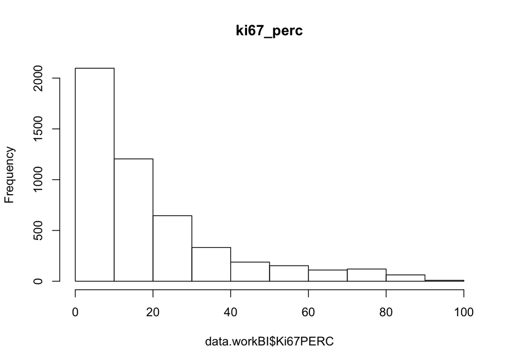

```r
data.workBI$Ki67_biop_bi <- factor(ifelse(data.workBI$breast_biop %in% c("L"), as.character(data.workBI$Ki67_biop_bi_L), as.character(data.workBI$Ki67_biop_bi_R)))

data.workBI$Ki67_biop <- factor(ifelse(data.workBI$breast_biop %in% c("L"), as.numeric(data.workBI$Ki67_biop_L), as.numeric(data.workBI$Ki67_biop_R)))

data.workBI$Ki67_cl_biop <- factor(ifelse(data.workBI$breast_biop %in% c("L"), as.numeric(data.workBI$Ki67_cl_biop_L), as.numeric(data.workBI$Ki67_cl_biop_R)))

data.workBI$Ki67PERC <- as.numeric(ifelse(data.workBI$breast_biop %in% c("L"), as.character(data.workBI$POURCKI67_G_BI), as.character(data.workBI$POURCKI67_D_BI)))
hist(data.workBI$Ki67PERC, main = 'ki67_perc')
```

## Genomic test biopsy

```r
# Genomic test
data.workBI$genom_biop_bi <- factor(ifelse(data.workBI$breast_biop %in% c("L"), as.character(data.workBI$genom_biop_bi_L), as.character(data.workBI$genom_biop_bi_R)))

table(data.workBI$genom_biop_bi, exclude = NULL)
```

```
##
##     done not done     <NA>
##       85     4894     4534
```

# Surgery

Correction erreurs equipe Dijon

```r
data.workM0$DTBILANRENAL_M[which(data.workM0$SUBJID=="16-10081" & data.workM0$DTBILANRENAL_M=="19/12/0217")] = "19/12/2017"
data.workM0$DTDERNTT_M0[which(data.workM0$SUBJID=="01-07259" & data.workM0$DTDERNTT_M0=="08/72/015")] = "08/07/2015"
data.workM0$DTDERNTT_M0[which(data.workM0$SUBJID=="01-09652" & data.workM0$DTDERNTT_M0=="11/10/1201")] = "11/10/2011"
data.workM0$DTDERNTT_M0[which(data.workM0$SUBJID=="07-06813" & data.workM0$DTDERNTT_M0=="00/11/2015")] = "15/11/2015"
data.workM0$DTDERNTT_M0[which(data.workM0$SUBJID=="20-08642" & data.workM0$DTDERNTT_M0=="17/06/1016")] = "17/06/2016"
data.workM0$DTDERNREGL_M0[which(data.workM0$SUBJID=="01-09821" & data.workM0$DTDERNREGL_M0=="KN/KN/NK")] = "NK/NK/NK";
data.workM0$DTDERNREGL_M0[which(data.workM0$SUBJID=="12-02818" & data.workM0$DTDERNREGL_M0=="NK06/2014")] = "NK/06/2014"
```

Check variables different from NAs

```r
data.work$surg_info <- rep(NA, nrow(data.work))

var_right_surg=c("pT_R","pN_R","nbggpos_R","taillehisto_R","multifocal_R","infiltrant_cancer_surg_R",
                                    "histo_4cl_surg_R","histo_3cl_surg_R","grade_3cl_surg_R","grade_2cl_surg_R",
                                    "index_mitotic_surg_R","dcis_surg_R","surgery_R","breast_surgery_R",
                                    "axillary_surgery_R","comp_post_surg_R","er_surg_R","perc_er_surg_R",
                                    "inte_er_surg_R","pr_surg_R","perc_pr_surg_R","inte_pr_surg_R","her2_surg_R",
                                    "her2_ihc_surg_R","Ki67_surg_bi_R","Ki67_surg_R","Ki67_cl_surg_R","genom_surg_bi_R")

var_left_surg=c("pT_L","pN_L","nbggpos_L","taillehisto_L","multifocal_L","infiltrant_cancer_surg_L",
           "histo_4cl_surg_L","histo_3cl_surg_L","grade_3cl_surg_L","grade_2cl_surg_L",
           "index_mitotic_surg_L","dcis_surg_L","surgery_L","breast_surgery_L",
           "axillary_surgery_L","comp_post_surg_L","er_surg_L","perc_er_surg_L",
           "inte_er_surg_L","pr_surg_L","perc_pr_surg_L","inte_pr_surg_L","her2_surg_L",
           "her2_ihc_surg_L","Ki67_surg_bi_L","Ki67_surg_L","Ki67_cl_surg_L","genom_surg_bi_L")

data.work$surg_info <- apply(data.work[,c(var_left_surg,var_right_surg)],
                           1,function(x) sum(!is.na(x)))
```

## Individuals with unilateral cancer, but with informations for both sides

```r
incompability2 <- function(data, var_left, var_right){

  warning <- rep(0,nrow(data))
  for (i in 1:nrow(data)) {
    for (c in 1:length(var_left)) {
      if(warning[i]==0){
        warning[i] <- ifelse(!is.na(data[i,which(colnames(data)==var_left[c])]) & !is.na(data[i,which(colnames(data)==var_right[c])]),1,0)
        #if(warning[i]==1){
          #print(paste(i,var_left[c], data[i,which(colnames(data)==var_left[c])], data[i,which(colnames(data)==var_right[c])]))
        #}
      }

    }
  }

  return(warning)
}



incomp <- incompability2(data.work,

                        var_right = var_right_surg,
                        var_left = var_left_surg)


data.work$warning_surg <- incomp
table(data.work$warning_surg, exclude = NULL)
```

```
##
##    0    1
## 9491   22
```

We have 22 patients with informations on both sides but with unilateral cancer. Here the table for surgery related variables for these patients. Every patient has 2 rows: one for left and one for right breast side.

```r
columns = which(data.work$warning_surg == 1)
rr = as.data.frame(matrix(NA, nrow = 2*length(columns), ncol=length(var_left_surg)+4))
rr[,3] = rep(c("L","R"),length(columns))
colnames(rr) = c("ID", "OFFICIAL SIDE", "INSPECTED SIDE", "# NOT NA", unlist(lapply(var_left_surg, function(x){substr(x,0,nchar(x)-2)})))
i = 1
for(c in columns){
  rr[i,1] = c
  rr[i+1,1] = c
  rr[i,2] = if(data.work$LOC[c]==1) "L" else "R"
  rr[i+1,2] = if(data.work$LOC[c]==1) "L" else "R"
  rr[i,4] = length(which(!is.na(data.work[c,var_left_surg])))
  rr[i+1,4] = length(which(!is.na(data.work[c,var_right_surg])))
  rr[i,5:ncol(rr)] = data.work[c,var_left_surg]
  rr[i+1,5:ncol(rr)] = data.work[c,var_right_surg]
  i = i + 2
}
rr
```

| ID | OFFICIAL SIDE | INSPECTED SIDE | # NOT NA | pT | pN | nbggpos | taillehisto | multifocal | infiltrant_cancer_surg | histo_4cl_surg | histo_3cl_surg | grade_3cl_surg | grade_2cl_surg | index_mitotic_surg | dcis_surg | surgery | breast_surgery | axillary_surgery | comp_post_surg | er_surg | perc_er_surg | inte_er_surg | pr_surg | perc_pr_surg | inte_pr_surg | her2_surg | her2_ihc_surg | Ki67_surg_bi | Ki67_surg | … |
| --- | --- | --- | --- | --- | --- | --- | --- | --- | --- | --- | --- | --- | --- | --- | --- | --- | --- | --- | --- | --- | --- | --- | --- | --- | --- | --- | --- | --- | --- | --- |
| 5 | R | L | 1 | NA | NA | NA | NA | NA | NA | NA | NA | NA | NA | NA | NA | NA | NA | NA | 1 | NA | NA | NA | NA | NA | NA | NA | NA | NA | NA | … |
| 5 | R | R | 22 | 1 | 0 | 0 | 12 | 1 | 2 | 1 | 1 | 2 | 1 | 2 | 2 | 2 | 1 | 2 | 1 | NA | NA | NA | NA | NA | NA | 2 | 3 | 2 | 15 | … |
| 440 | L | L | 18 | 2 | 0 | 0 | 22 | 1 | 2 | 1 | 1 | 3 | 2 | 2 | 2 | 2 | 1 | 2 | 1 | NA | NA | NA | NA | NA | NA | NA | NA | 1 | NA | … |
| 440 | L | R | 4 | NA | NA | NA | NA | NA | NA | NA | NA | NA | NA | NA | NA | 2 | 1 | 4 | 1 | NA | NA | NA | NA | NA | NA | NA | NA | NA | NA | … |
| 625 | L | L | 17 | 2 | 1 | 2 | 40 | 1 | 2 | 1 | 1 | 2 | 1 | 3 | 2 | 2 | 2 | 1 | 1 | NA | NA | NA | NA | NA | NA | NA | NA | NA | NA | … |
| 625 | L | R | 3 | NA | NA | NA | NA | NA | NA | NA | NA | NA | NA | NA | NA | NA | 2 | 1 | 1 | NA | NA | NA | NA | NA | NA | NA | NA | NA | NA | … |
| 999 | R | L | 22 | 1 | 1 | 2 | 6 | 1 | 2 | 4 | 3 | 3 | 2 | 2 | 2 | 2 | 2 | 3 | 1 | 2 | NA | NA | 2 | NA | NA | 2 | 1 | 1 | NA | … |
| 999 | R | R | 23 | 1 | 0 | 0 | 10 | 1 | 2 | 1 | 1 | 3 | 2 | 2 | 2 | 2 | 1 | 2 | 1 | 1 | NA | 3 | 2 | NA | NA | 1 | 4 | 1 | NA | … |
| 1886 | L | L | 28 | 1 | 0 | 0 | 11 | 1 | 2 | 1 | 1 | 2 | 1 | 1 | 2 | 2 | 1 | 2 | 1 | 1 | 100 | 3 | 1 | 100 | 3 | 2 | 1 | 2 | 15 | … |
| 1886 | L | R | 1 | NA | NA | NA | NA | NA | NA | NA | NA | NA | NA | NA | NA | 1 | NA | NA | NA | NA | NA | NA | NA | NA | NA | NA | NA | NA | NA | … |

[output cut: 34 more lines]

As you can see from the table, we can assign surgery side to the correct side reported as variable “LOC”, the few wrong side columns are probably filled as an error.

## Define surgery side based on left or right breast surgery:

Is it consistent with breast side?

```r
left_right <- function(data, var_left, var_right){

  side <- rep(NA,nrow(data))
  for (i in 1:nrow(data)) {
    for (l in var_left) {
      if(data[i,"warning_surg"]==0){
        side[i] <- ifelse(!is.na(data[i,l]), "L", side[i])
      }
      if(data[i,"warning_surg"]==1){
        side[i] <- NA
      }
    }
    for (r in var_right) {
      if(data[i,"warning_surg"]==0){
        side[i] <- ifelse(!is.na(data[i,r]), "R", side[i])
      }
      if(data[i,"warning_surg"]==1){
        side[i] <- NA
      }
    }
  }

  return(side)

}

side <- left_right(data.work,
                   var_right=var_right_surg,
                   var_left=var_left_surg)

data.work$breast_surg_side <- as.factor(side)

table(data.work$breast_surg_side,data.work$warning_surg, exclude = NULL, dnn = c("SIDE", "Info both L/R"))
```

```
##       Info both L/R
## SIDE      0    1
##   L    4802    0
##   R    4598    0
##   <NA>   91   22
```

We have 91 individuals with unilateral cancer with no information on left or right breast and 22 individuals with informations on both sides but with unilateral cancer.

# We keep the side for surgery as the one saved in variable LOC.

## Surgery performed

```r
data.work$surgery <- factor(ifelse(data.work$breast_surg_side %in% c("L"), as.character(data.work$surgery_L), as.character(data.work$surgery_R)))
table(data.work$surgery, exclude = NULL)
```

```
##
##   no  yes <NA>
##   24 9394   95
```

## Check NA values

We have 95 patients with NA as surgery.

4 of them has information on surgery variables.

```r
v = which(is.na(data.work$surgery) & data.work$surg_info >1)
columns = v
rr = as.data.frame(matrix(NA, nrow = 2*length(columns), ncol=length(var_left_surg)+4))
rr[,3] = rep(c("L","R"),length(columns))
colnames(rr) = c("ID", "OFFICIAL SIDE", "INSPECTED SIDE", "# NOT NA", unlist(lapply(var_left_surg, function(x){substr(x,0,nchar(x)-2)})))
i = 1
for(c in columns){
  rr[i,1] = c
  rr[i+1,1] = c
  rr[i,2] = if(data.work$LOC[c]==1) "L" else "R"
  rr[i+1,2] = if(data.work$LOC[c]==1) "L" else "R"
  rr[i,4] = length(which(!is.na(data.work[c,var_left_surg])))
  rr[i+1,4] = length(which(!is.na(data.work[c,var_right_surg])))
  rr[i,5:ncol(rr)] = data.work[c,var_left_surg]
  rr[i+1,5:ncol(rr)] = data.work[c,var_right_surg]
  i = i + 2
}
rr
```

| ID | OFFICIAL SIDE | INSPECTED SIDE | # NOT NA | pT | pN | nbggpos | taillehisto | multifocal | infiltrant_cancer_surg | histo_4cl_surg | histo_3cl_surg | grade_3cl_surg | grade_2cl_surg | index_mitotic_surg | dcis_surg | surgery | breast_surgery | axillary_surgery | comp_post_surg | er_surg | perc_er_surg | inte_er_surg | pr_surg | perc_pr_surg | inte_pr_surg | her2_surg | her2_ihc_surg | Ki67_surg_bi | Ki67_surg | … |
| --- | --- | --- | --- | --- | --- | --- | --- | --- | --- | --- | --- | --- | --- | --- | --- | --- | --- | --- | --- | --- | --- | --- | --- | --- | --- | --- | --- | --- | --- | --- |
| 1879 | R | L | 0 | NA | NA | NA | NA | NA | NA | NA | NA | NA | NA | NA | NA | NA | NA | NA | NA | NA | NA | NA | NA | NA | NA | NA | NA | NA | NA | … |
| 1879 | R | R | 24 | 1 | 0 | 0 | 9 | 1 | 2 | 1 | 1 | 1 | 1 | 1 | 2 | NA | NA | NA | NA | 1 | 100 | 3 | 1 | 40 | 3 | 2 | 2 | 2 | 5 | … |
| 7151 | R | L | 0 | NA | NA | NA | NA | NA | NA | NA | NA | NA | NA | NA | NA | NA | NA | NA | NA | NA | NA | NA | NA | NA | NA | NA | NA | NA | NA | … |
| 7151 | R | R | 14 | 1 | 1 | 0 | 15 | 2 | 2 | 1 | 1 | 1 | 1 | 1 | 1 | NA | NA | NA | NA | NA | NA | NA | NA | NA | NA | NA | NA | 1 | NA | … |
| 7997 | R | L | 17 | 1 | 0 | 0 | 9 | 1 | 2 | 4 | 3 | 3 | 2 | 3 | 1 | 2 | 1 | 1 | 2 | NA | NA | NA | NA | NA | NA | NA | NA | NA | NA | … |
| 7997 | R | R | 0 | NA | NA | NA | NA | NA | NA | NA | NA | NA | NA | NA | NA | NA | NA | NA | NA | NA | NA | NA | NA | NA | NA | NA | NA | NA | NA | … |
| 9001 | R | L | 0 | NA | NA | NA | NA | NA | NA | NA | NA | NA | NA | NA | NA | NA | NA | NA | NA | NA | NA | NA | NA | NA | NA | NA | NA | NA | NA | … |
| 9001 | R | R | 4 | 4 | 4 | NA | NA | NA | 1 | NA | NA | NA | NA | NA | NA | NA | NA | NA | NA | NA | NA | NA | NA | NA | NA | NA | NA | NA | NA | … |

Set them as having had surgery, all other NAs as not having has surgery

```r
data.work$surgery[v] = 'yes'
data.work$surgery[which(is.na(data.work$surgery))] = 'no'
```

The new data distribution is:

```r
table(data.work$surgery, exclude = NULL)
```

```
##
##   no  yes
##  115 9398
```

## pT

```r
data.work$pT <- factor(ifelse(data.work$breast_surg_side %in% c("L"), as.numeric(data.work$pT_L), as.numeric(data.work$pT_R)))
table(data.work$pT, exclude = NULL)
```

```
##
##    0    1    2    3    4 <NA>
##  475 6187 2246  302   25  278
```

## pN

```r
data.work$pN <- factor(ifelse(data.work$breast_surg_side %in% c("L"), as.numeric(data.work$pN_L), as.numeric(data.work$pN_R)))
table(data.work$pN, exclude = NULL)
```

```
##
##    0    1    2    3    4 <NA>
## 6133 2364  518  189   32  277
```

## nbggpos

```r
data.work$nbggpos <- factor(ifelse(data.work$breast_surg_side %in% c("L"), as.numeric(data.work$nbggpos_L), as.numeric(data.work$nbggpos_R)))
table(data.work$nbggpos, exclude = NULL)
```

```
##
##    0    1    2    3    4    5    6    7    8    9   10   11   12   13   14   15
## 5847 1502  589  242  180  107   81   78   40   41   35   23   20   18   15   11
##   16   17   18   19   20   21   22   23   24   25   26   27   29   32   35   37
##    4    9    5    8    7    3    6    1    6    2    2    2    2    2    1    1
## <NA>
##  623
```

## taillehisto

```r
data.work$taillehisto <- factor(ifelse(data.work$breast_surg_side %in% c("L"), as.numeric(data.work$taillehisto_L), as.numeric(data.work$taillehisto_R)))
table(data.work$taillehisto, exclude = NULL)
```

```
##
##    0  0.1  0.6  0.7    1  1.2  1.5  1.7  1.8    2  2.5    3  3.2  3.5    4  4.5
##  304    1    1    1   46    1    3    1    2   49    2   51    1    3   90    2
##    5  5.5  5.6    6  6.4  6.5    7  7.5    8    9   10   11   12   13   14   15
##  177    2    2  211    1    1  337    2  409  336  571  373  559  356  278  724
##   16   17   18   19   20   21   22   23   24   25   26   27   28   29   30   31
##  231  317  342  143  492  134  234  122  105  355   69  107   94   26  292   22
##   32   33   34   35   36   37   38   39   40   41   42   43   44   45   46   47
##   56   29   23  167   17   19   19    6  137    2   16    7    3   82    2   10
##   48   49   50   51   52   53   54   55   56   57   58   60   61   62   63   64
##    9    4   68    1    7    1    1   32    5    1    4   56    1    2    2    1
##   65   67   70   74   75   77   78   80   82   84   85   88   90   95  100  105
##   23    1   37    1   12    1    1   38    1    1    4    1   10    3   19    1
##  110  111  112  120  123  125  130  140  150  160  180  200  220  230  250  320
##    4    1    1    5    1    1    3    4    2    2    3    4    1    1    1    1
##  400  500  700  750  800 <NA>
##    1    1    1    2    1  546
```

## multifocal_surg

```r
data.work$multifocal_surg <- factor(ifelse(data.work$breast_surg_side %in% c("L"), as.character(data.work$multifocal_L), as.character(data.work$multifocal_R)))
table(data.work$multifocal_surg, exclude = NULL)
```

```
##
##   no  yes <NA>
## 7305 1860  348
```

## breast_surgery_cl

```r
data.work$breast_surgery_cl <- factor(ifelse(data.work$breast_surg_side %in% c("L"), as.character(data.work$breast_surgery_L), as.character(data.work$breast_surgery_R)))
table(data.work$multifocal_surg, exclude = NULL)
```

```
##
##   no  yes <NA>
## 7305 1860  348
```

## Axillary surgery

```r
data.work$axillary_surgery <- factor(ifelse(data.work$breast_surg_side %in% c("L"), as.character(data.work$axillary_surgery_L), as.character(data.work$axillary_surgery_R)))
table(data.work$axillary_surgery, exclude = NULL)
```

```
##
##  AND BOTH NONE  SNB <NA>
## 2262 1264   99 5769  119
```

## Complications post surgery

```r
data.work$comp_post_surg <- factor(ifelse(data.work$breast_surg_side %in% c("L"), as.character(data.work$comp_post_surg_L), as.character(data.work$comp_post_surg_R)))
table(data.work$comp_post_surg, exclude = NULL)
```

```
##
##   no  yes <NA>
## 7804 1560  149
```

## infiltrant_cancer_surg surgery

```r
data.work$infiltrant_cancer_surg <- factor(ifelse(data.work$breast_surg_side %in% c("L"),
                                                    as.character(data.work$infiltrant_cancer_surg_L), as.character(data.work$infiltrant_cancer_surg_R)))
table(data.work$infiltrant_cancer_surg, exclude = NULL)
```

```
##
##   no  yes <NA>
##  565 8675  273
```

## histo_4cl surgery

```r
data.work$histo_4cl_surg <- factor(ifelse(data.work$breast_surg_side %in% c("L"), as.character(data.work$histo_4cl_surg_L), as.character(data.work$histo_4cl_surg_R)))
table(data.work$histo_4cl_surg, exclude = NULL)
```

```
##
## lobular   mixed     NST  others    <NA>
##    1166     199    6643     607     898
```

## histo_3cl surgery

```r
# histological type (3 classes)
data.work$histo_3cl_surg <- data.work$histo_4cl_surg
levels(data.work$histo_3cl_surg) <- c("NST","lobular","others","others")
table(data.work$histo_3cl_surg, exclude = NULL)
```

```
##
##     NST lobular  others    <NA>
##    1166     199    7250     898
```

## Mitotic index surgery

```r
# Mitotic index
data.work$index_mitotic_surg <- factor(ifelse(data.work$breast_surg_side %in% c("L"), as.numeric(data.work$index_mitotic_surg_L), as.numeric(data.work$index_mitotic_surg_R)))
table(data.work$index_mitotic_surg, exclude = NULL)
```

```
##
##    1    2    3 <NA>
## 4943 1646 1458 1466
```

## dcis_surg

```r
# In situ
data.work$dcis_surg <- factor(ifelse(data.work$breast_surg_side %in% c("L"), as.character(data.work$dcis_surg_L), as.character(data.work$dcis_surg_R)))
table(data.work$dcis_surg, exclude = NULL)
```

```
##
##   no  yes <NA>
## 3206 5851  456
```

## Grade 3cl surgery

```r
data.work$grade_3cl_surg <- factor(ifelse(data.work$breast_surg_side %in% c("L"), as.character(data.work$grade_3cl_surg_L), as.character(data.work$grade_3cl_surg_R)))
table(data.work$grade_3cl_surg, exclude = NULL)
```

```
##
##   Grade I  Grade II Grade III      <NA>
##      2058      4190      1998      1267
```

## ER status

```r
data.work$er_surg <- factor(ifelse(data.work$breast_surg_side %in% c("L"), as.character(data.work$er_surg_L), as.character(data.work$er_surg_R)))
table(data.work$er_surg, exclude = NULL)
```

```
##
## negative positive     <NA>
##      880     4576     4057
```

```r
# Percentage
data.work$perc_er_surg <- factor(ifelse(data.work$breast_surg_side %in% c("L"), as.numeric(data.work$perc_er_surg_L), as.numeric(data.work$perc_er_surg_R)))

# Intensity
data.work$inte_er_surg <- factor(ifelse(data.work$breast_surg_side %in% c("L"), as.numeric(data.work$inte_er_surg_L), as.numeric(data.work$inte_er_surg_R)))
```

## PR status surgery

```r
# PR status
data.work$pr_surg <- factor(ifelse(data.work$breast_surg_side %in% c("L"), as.character(data.work$pr_surg_L), as.character(data.work$pr_surg_R)))
table(data.work$pr_surg, exclude = NULL)
```

```
##
## negative positive     <NA>
##     1683     3810     4020
```

```r
# Percentage
data.work$perc_pr_surg <- factor(ifelse(data.work$breast_surg_side %in% c("L"), as.numeric(data.work$perc_pr_surg_L), as.numeric(data.work$perc_pr_surg_R)))

# Intensity
data.work$inte_pr_surg <- factor(ifelse(data.work$breast_surg_side %in% c("L"), as.numeric(data.work$inte_pr_surg_L), as.numeric(data.work$inte_pr_surg_R)))
```

## HER2 status surgery -> inconsistency between CANTO1 data and rules by DIJON

```r
data.work$her2_surg <- factor(ifelse(data.work$breast_surg_side %in% c("L"), as.character(data.work$her2_surg_L), as.character(data.work$her2_surg_R)))

table(data.work$her2_surg, exclude = NULL)
```

```
##
## negative positive     <NA>
##     5911      807     2795
```

```r
data.work$her2_ihc_surg <- factor(ifelse(data.work$breast_surg_side %in% c("L"), as.character(data.work$her2_ihc_surg_L), as.character(data.work$her2_ihc_surg_R)))

data.work$fish_surg <- factor(ifelse(data.work$breast_surg_side %in% c("L"), as.character(data.work$fish_surg_L), as.character(data.work$fish_surg_R)))


data.work$her2_surg2 = factor(NA, levels = c("positive","negative"))
data.work$her2_surg2[which(data.work$her2_ihc_surg == '3+' | data.work$fish_surg == 'positive')] = 'positive'
data.work$her2_surg2[which(data.work$her2_ihc_surg == '0' | data.work$her2_ihc_surg == '1+' | ( data.work$her2_ihc_surg == '2+' &  (data.work$fish_surg == 'negative' | is.na(data.work$fish_surg))))] = 'negative'

data.work$her2_surg2[which(is.na(data.work$her2_surg2))] = data.work$her2_surg[which(is.na(data.work$her2_surg2))]

table(her2_canto = data.work$her2_surg , her2_Dijon = data.work$her2_surg2, exclude = NULL)
```

```
##           her2_Dijon
## her2_canto positive negative <NA>
##   negative        4     5907    0
##   positive      602      205    0
##   <NA>            0       34 2761
```

Take new rules by Dijon

```r
data.work$her2_surg = data.work$her2_surg2
```

## KI67 status surgery

```r
# Ki67 status
data.work$Ki67_surg_bi <- factor(ifelse(data.work$breast_surg_side %in% c("L"), as.character(data.work$Ki67_surg_bi_L), as.character(data.work$Ki67_surg_bi_R)))

data.work$Ki67_surg <- factor(ifelse(data.work$breast_surg_side %in% c("L"), as.numeric(data.work$Ki67_surg_L), as.numeric(data.work$Ki67_surg_R)))

data.work$Ki67_cl_surg <- factor(ifelse(data.work$breast_surg_side %in% c("L"), as.character(data.work$Ki67_cl_surg_L), as.character(data.work$Ki67_cl_surg_R)))
table(data.work$Ki67_cl_surg, exclude = NULL)
```

```
##
## high  low <NA>
## 2074 3062 4377
```

## Genomic test surgery

```r
# Genomic test
data.work$genom_surg_bi <- factor(ifelse(data.work$breast_surg_side %in% c("L"), as.character(data.work$genom_surg_bi_L), as.character(data.work$genom_surg_bi_R)))
table(data.work$genom_surg_bi, exclude = NULL)
```

```
##
##     done not done     <NA>
##      352     8878      283
```

# Chemotherapy

## Chemiotherapy status

```r
data.work$CT <- factor(NA, levels = c("no","yes"))
data.work$CT[which(data.work$CHIMIO==0)] <- "no"
data.work$CT[which(data.work$CHIMIO==1)] <- "yes"

table(data.work$CT, exclude = NULL)
```

```
##
##   no  yes <NA>
## 4484 4923  106
```

## Check NAs

```r
cols_chemo = c("CHIMIOADJ","SEQCHIMIO_ADJ","SEQ1_ADJ","SEQ2_ADJ",
               "OTHSEQ1_ADJ","OTHSEQ2_ADJ","REDUCDOSE_ADJ","FACTCROISS_ADJ",
               "CHIMIONEO","SEQCHIMIO_NEO","SEQ1_NEO","SEQ2_NEO",
               "OTHSEQ1_NEO","OTHSEQ2_NEO","REDUCDOSE_NEO","FACTCROISS_NEO", "SATALOFF1_G_M0","SATALOFF2_G_M0",
               "SATALOFF1_D_M0","SATALOFF2_D_M0")

cols_chemo_neo = c("CHIMIONEO","SEQCHIMIO_NEO","SEQ1_NEO","SEQ2_NEO",
               "OTHSEQ1_NEO","OTHSEQ2_NEO","REDUCDOSE_NEO","FACTCROISS_NEO", "SATALOFF1_G_M0","SATALOFF2_G_M0",
               "SATALOFF1_D_M0","SATALOFF2_D_M0")

cols_chemo_adj = c("CHIMIOADJ","SEQCHIMIO_ADJ","SEQ1_ADJ","SEQ2_ADJ",
               "OTHSEQ1_ADJ","OTHSEQ2_ADJ","REDUCDOSE_ADJ","FACTCROISS_ADJ")
```

We have 106 patients with NA as chemotherapy status, counting both neoadj and adj. 0 of them has information on chemotherapy variables:

```r
rr= cbind(data.work[which(is.na(data.work$CT) & data.work$CT_info!=0),cols_chemo])
rr
```

| CHIMIOADJ | SEQCHIMIO_ADJ | SEQ1_ADJ | SEQ2_ADJ | OTHSEQ1_ADJ | OTHSEQ2_ADJ | REDUCDOSE_ADJ | FACTCROISS_ADJ | CHIMIONEO | SEQCHIMIO_NEO | SEQ1_NEO | SEQ2_NEO | OTHSEQ1_NEO | OTHSEQ2_NEO | REDUCDOSE_NEO | FACTCROISS_NEO | SATALOFF1_G_M0 | SATALOFF2_G_M0 | SATALOFF1_D_M0 | SATALOFF2_D_M0 |
| --- | --- | --- | --- | --- | --- | --- | --- | --- | --- | --- | --- | --- | --- | --- | --- | --- | --- | --- | --- |

There are 0 column different from NA -> we can set chemotherapy to no for all NAs.

We now have:

```
##
##   no  yes
## 4590 4923
```

## CT set to no, but neoadjuvant chemotherapy set to yes

```r
v = which(data.work$CHIMIO == 0 & data.work$CHIMIONEO==1)
rr = cbind(data.work[v,cols_chemo])

rr
```

|  | CHIMIOADJ | SEQCHIMIO_ADJ | SEQ1_ADJ | SEQ2_ADJ | OTHSEQ1_ADJ | OTHSEQ2_ADJ | REDUCDOSE_ADJ | FACTCROISS_ADJ | CHIMIONEO | SEQCHIMIO_NEO | SEQ1_NEO | SEQ2_NEO | OTHSEQ1_NEO | OTHSEQ2_NEO | REDUCDOSE_NEO | FACTCROISS_NEO | SATALOFF1_G_M0 | SATALOFF2_G_M0 | SATALOFF1_D_M0 | SATALOFF2_D_M0 |
| --- | --- | --- | --- | --- | --- | --- | --- | --- | --- | --- | --- | --- | --- | --- | --- | --- | --- | --- | --- | --- |
| 52 | 0 | NA | NA | NA | NA | NA | NA | NA | 1 | 2 | 1 | 5 | NA | NA | 0 | 0 | NA | NA | T-D | NA |
| 170 | 0 | NA | NA | NA | NA | NA | NA | NA | 1 | 2 | 1 | 5 | NA | NA | 0 | 0 | NA | NA | T-A | N-A |
| 228 | 0 | NA | NA | NA | NA | NA | NA | NA | 1 | 2 | 1 | 5 | NA | NA | 0 | 0 | NA | NA | T-A | N-A |
| 2246 | 0 | NA | NA | NA | NA | NA | NA | NA | 1 | 2 | 6 | 6 | EPIRUBICINE - ENDOXAN | TAXOL HEBDO | 0 | 0 | T-A | N-B | NA | NA |
| 2270 | 0 | NA | NA | NA | NA | NA | NA | NA | 1 | 2 | 1 | 6 | NA | TAXOL | 0 | 0 | NA | NA | T-A | N-B |
| 2372 | 0 | NA | NA | NA | NA | NA | NA | NA | 1 | 2 | 1 | 5 | NA | NA | 0 | 0 | T-A | N-B | NA | NA |
| 2462 | 0 | NA | NA | NA | NA | NA | NA | NA | 1 | 2 | 1 | 5 | NA | NA | 0 | NA | NA | NA | T-B | N-A |
| 2466 | 0 | NA | NA | NA | NA | NA | NA | NA | 1 | 2 | 1 | 5 | NA | NA | 0 | NA | NA | NA | T-A | N-B |
| 2469 | 0 | NA | NA | NA | NA | NA | NA | NA | 1 | 2 | 1 | 5 | NA | NA | 0 | NA | NA | NA | NA | NA |
| 2507 | 0 | NA | NA | NA | NA | NA | NA | NA | 1 | 2 | 1 | 5 | NA | NA | 1 | 1 | NA | NA | T-A | N-A |

[output cut: 27 more lines]

We set chemotherapy to yes for these patients

```r
data.work$CT[v] <- 'yes'
data.work$CHIMIO[v] <- 1
```

## CT set to no, but adjuvant chemotherapy set to yes

```r
v = which(data.work$CHIMIO == 0 & data.work$CHIMIOADJ==1)
rr = cbind(data.work[v,cols_chemo])

rr
```

|  | CHIMIOADJ | SEQCHIMIO_ADJ | SEQ1_ADJ | SEQ2_ADJ | OTHSEQ1_ADJ | OTHSEQ2_ADJ | REDUCDOSE_ADJ | FACTCROISS_ADJ | CHIMIONEO | SEQCHIMIO_NEO | SEQ1_NEO | SEQ2_NEO | OTHSEQ1_NEO | OTHSEQ2_NEO | REDUCDOSE_NEO | FACTCROISS_NEO | SATALOFF1_G_M0 | SATALOFF2_G_M0 | SATALOFF1_D_M0 | SATALOFF2_D_M0 |
| --- | --- | --- | --- | --- | --- | --- | --- | --- | --- | --- | --- | --- | --- | --- | --- | --- | --- | --- | --- | --- |
| 1783 | 1 | 2 | 1 | 6 | NA | PACLITAXEL HEBDOMADAIRE | 1 | 0 | 0 | NA | NA | NA | NA | NA | NA | NA | NA | NA | NA | NA |

We set chemotherapy to yes for this patient

```r
data.work$CT[v] <- 'yes'
data.work$CHIMIO[v] <- 1
```

## CT or neoadj CT set to no, but sataloff (neoadj) is known

```r
# table(chemo_variables_not_na=data.work$CT_info,chemotherapy = data.work$CT)
v = which((data.work$CT %in% c("no") | data.work$CHIMIONEO %in% c(0)) & (!is.na(data.work$SATALOFF1_G_M0) |  !is.na(data.work$SATALOFF1_D_M0) ))

rr = data.work[v,cols_chemo]
rr
```

|  | CHIMIOADJ | SEQCHIMIO_ADJ | SEQ1_ADJ | SEQ2_ADJ | OTHSEQ1_ADJ | OTHSEQ2_ADJ | REDUCDOSE_ADJ | FACTCROISS_ADJ | CHIMIONEO | SEQCHIMIO_NEO | SEQ1_NEO | SEQ2_NEO | OTHSEQ1_NEO | OTHSEQ2_NEO | REDUCDOSE_NEO | FACTCROISS_NEO | SATALOFF1_G_M0 | SATALOFF2_G_M0 | SATALOFF1_D_M0 | SATALOFF2_D_M0 |
| --- | --- | --- | --- | --- | --- | --- | --- | --- | --- | --- | --- | --- | --- | --- | --- | --- | --- | --- | --- | --- |
| 392 | 1 | 2 | 1 | 5 | NA | NA | 0 | 1 | 0 | NA | NA | NA | NA | NA | NA | NA | T-C | NA | NA | NA |
| 1128 | 1 | 2 | 1 | 6 | NA | TAXOL | 0 | 0 | 0 | NA | NA | NA | NA | NA | NA | NA | NA | NA | T-A | N-A |
| 1242 | 1 | 2 | 6 | 5 | EC | NA | 0 | 0 | 0 | NA | NA | NA | NA | NA | NA | NA | T-D | NA | NA | NA |
| 1946 | 1 | 2 | 1 | 5 | NA | NA | 0 | 0 | 0 | NA | NA | NA | NA | NA | NA | NA | T-C | N-B | NA | NA |
| 2008 | NA | NA | NA | NA | NA | NA | NA | NA | 0 | NA | NA | NA | NA | NA | NA | NA | T-C | N-B | NA | NA |
| 3315 | NA | NA | NA | NA | NA | NA | NA | NA | 0 | NA | NA | NA | NA | NA | NA | NA | T-C | NA | NA | NA |
| 4183 | 1 | 2 | 1 | 5 | NA | NA | 0 | 1 | 0 | NA | NA | NA | NA | NA | NA | NA | T-B | N-C | NA | NA |
| 4367 | 1 | 2 | 1 | 5 | NA | NA | 0 | 1 | 0 | NA | NA | NA | NA | NA | NA | NA | T-C | N-C | NA | NA |
| 4471 | 1 | 2 | 1 | 5 | NA | NA | 1 | 1 | 0 | NA | NA | NA | NA | NA | NA | NA | T-A | N-A | NA | NA |
| 4512 | 1 | 2 | 1 | 3 | NA | NA | 0 | 1 | 0 | NA | NA | NA | NA | NA | NA | NA | T-A | N-B | NA | NA |

[output cut: 4 more lines]

We have 14 for which SATALOFF1 is defined. We set chemotherapy and neoadjuvant chemotherapy to yes.

```r
data.work$CHIMIONEO[v] <- 1
data.work$CHIMIO[v] <- 1
data.work$CT[v] <- "yes"
```

```r
data.work$CHIMIOADJ[v] <- 1
data.work$CT[v] <- "yes"
```

## Check all other cases where we have information on chemotherapy variables and CT = no

```r
table(chemo_variables_not_na=data.work$CT_info,chemotherapy = data.work$CT)
```

```
##                       chemotherapy
## chemo_variables_not_na   no  yes
##                     0  4544    2
##                     1     3    1
##                     2     1    6
##                     3     0   20
##                     4     0  358
##                     5     0 2815
##                     6     0  739
##                     7     0  781
##                     8     0  190
##                     9     0   22
##                     10    0    4
##                     11    0    7
##                     12    0   14
##                     13    0    6
```

```r
rr = cbind(data.work[which(data.work$CT %in% c("no") & data.work$CT_info>0),cols_chemo])
rr
```

|  | CHIMIOADJ | SEQCHIMIO_ADJ | SEQ1_ADJ | SEQ2_ADJ | OTHSEQ1_ADJ | OTHSEQ2_ADJ | REDUCDOSE_ADJ | FACTCROISS_ADJ | CHIMIONEO | SEQCHIMIO_NEO | SEQ1_NEO | SEQ2_NEO | OTHSEQ1_NEO | OTHSEQ2_NEO | REDUCDOSE_NEO | FACTCROISS_NEO | SATALOFF1_G_M0 | SATALOFF2_G_M0 | SATALOFF1_D_M0 | SATALOFF2_D_M0 |
| --- | --- | --- | --- | --- | --- | --- | --- | --- | --- | --- | --- | --- | --- | --- | --- | --- | --- | --- | --- | --- |
| 1262 | 0 | NA | 6 | NA | NA | NA | NA | NA | 0 | NA | NA | NA | NA | NA | NA | NA | NA | NA | NA | NA |
| 3007 | NA | NA | NA | NA | NA | TAXOL | NA | NA | NA | NA | NA | NA | NA | NA | NA | NA | NA | NA | NA | NA |
| 3986 | 0 | NA | NA | 5 | NA | NA | NA | NA | 0 | NA | NA | NA | NA | NA | NA | NA | NA | NA | NA | NA |
| 7249 | NA | NA | NA | NA | NA | NA | 0 | 0 | 0 | NA | NA | NA | NA | NA | NA | NA | NA | NA | NA | NA |

What to do with Other sequence taxol?

## Neo-adjuvant chemotherapy

### Neo-adjuvant chemotherapy status

```r
data.work$NAC_bin <- factor(NA, levels = c("no","yes"))
data.work$NAC_bin[which(data.work$CHIMIONEO==0)] <- "no"
data.work$NAC_bin[which(data.work$CHIMIONEO==1)] <- "yes"
data.work$NAC_bin[which(data.work$CT %in% c("no"))] <- "no"
data.work$NAC_bin[which(data.work$CT %in% c("yes") & !is.na(data.work$SATALOFF1_G_M0))] <- "yes"

summary(data.work$NAC_bin)
```

```
##   no  yes
## 8234 1279
```

We have no NAs for neo-adjuvant chemotherapy

### Check patients with neo-adjuvant chemotherapy set to no

```r
table(chemo_variables_not_na=data.work$CT_neo_info ,neoadj_chemotherapy = data.work$NAC_bin)
```

```
##                       neoadj_chemotherapy
## chemo_variables_not_na   no  yes
##                      0 8231    0
##                      1    1    4
##                      2    2   10
##                      4    0   19
##                      5    0  113
##                      6    0  208
##                      7    0  712
##                      8    0  195
##                      9    0   18
```

```r
rr = cbind(data.work[which(data.work$NAC_bin %in% c("no") & data.work$CT_neo_info>0),cols_chemo_neo])
rr
```

|  | CHIMIONEO | SEQCHIMIO_NEO | SEQ1_NEO | SEQ2_NEO | OTHSEQ1_NEO | OTHSEQ2_NEO | REDUCDOSE_NEO | FACTCROISS_NEO | SATALOFF1_G_M0 | SATALOFF2_G_M0 | SATALOFF1_D_M0 | SATALOFF2_D_M0 |
| --- | --- | --- | --- | --- | --- | --- | --- | --- | --- | --- | --- | --- |
| 7802 | 0 | NA | NA | 5 | NA | NA | NA | NA | NA | NA | NA | NA |
| 9411 | 0 | NA | NA | NA | NA | NA | 0 | 0 | NA | NA | NA | NA |
| 9420 | 0 | NA | NA | NA | NA | NA | 0 | 0 | NA | NA | NA | NA |

What to do with the patient with information on neo-adjuvant chemotherapy? For the moment we left them set to no

### Neo-adjuvant chemotherapy regimen

```r
chemo_types = read.xlsx('/Users/nadir/Desktop/projects/postdoc/DATABASES/databases/core/04_canto/src/Chemotherapy.xlsx', sheetIndex = 1)
chemo_types$TYPE = trim(as.character(chemo_types$TYPE ))
anthra = as.character((chemo_types %>% filter(TYPE=='anthra') %>% select(NAME))[,1])
taxanes = as.character((chemo_types %>% filter(TYPE=='taxanes') %>% select(NAME))[,1])
anthra_taxanes = as.character((chemo_types %>% filter(TYPE=='anthra-taxanes') %>% select(NAME))[,1])
others = as.character((chemo_types %>% filter(TYPE=='others') %>% select(NAME))[,1])

data.work$NAC_regimen <- factor(NA, levels = c("anthra-taxans", "anthra", "taxanes", "others"))

# mono sequential
data.work$NAC_regimen[
  which(data.work$NAC_bin %in% c("yes") & data.work$SEQCHIMIO_NEO==1 & data.work$SEQ1_NEO %in% c(1,2,3))] <- "anthra"
data.work$NAC_regimen[
  which(data.work$NAC_bin %in% c("yes") & data.work$SEQCHIMIO_NEO==1 & data.work$SEQ1_NEO %in% c(4))] <- "anthra-taxans"
data.work$NAC_regimen[
  which(data.work$NAC_bin %in% c("yes") & data.work$SEQCHIMIO_NEO==1 & data.work$SEQ1_NEO %in% c(5))] <- "taxanes"
data.work$NAC_regimen[
  which(data.work$NAC_bin %in% c("yes") & data.work$SEQCHIMIO_NEO==1 & data.work$SEQ1_NEO %in% c(6) &
          data.work$OTHSEQ1_NEO %in% taxanes)] <- "taxanes"
data.work$NAC_regimen[
  which(data.work$NAC_bin %in% c("yes") & data.work$SEQCHIMIO_NEO==1 & data.work$SEQ1_NEO %in% c(6) &
          data.work$OTHSEQ1_NEO %in% anthra)] <- "anthra"
data.work$NAC_regimen[
  which(data.work$NAC_bin %in% c("yes") & data.work$SEQCHIMIO_NEO==1 & data.work$SEQ1_NEO %in% c(6) &
          data.work$OTHSEQ1_NEO %in% anthra_taxanes)] <- "anthra-taxans"
data.work$NAC_regimen[
  which(data.work$NAC_bin %in% c("yes") & data.work$SEQCHIMIO_NEO==1 & data.work$SEQ1_NEO %in% c(6) &
          data.work$OTHSEQ1_NEO %in% others)] <- "others"



# bi-sequential
data.work$NAC_regimen[
  which(data.work$NAC_bin %in% c("yes") & data.work$SEQCHIMIO_NEO==2 & data.work$SEQ1_NEO %in% c(1,2,3) &
          data.work$SEQ2_NEO %in% c(1,2,3))] <- "anthra"
data.work$NAC_regimen[
  which(data.work$NAC_bin %in% c("yes") & data.work$SEQCHIMIO_NEO==2 & data.work$SEQ1_NEO %in% c(1,2,3) &
          data.work$SEQ2_NEO %in% c(5))] <- "anthra-taxans"
data.work$NAC_regimen[
  which(data.work$NAC_bin %in% c("yes") & data.work$SEQCHIMIO_NEO==2 & data.work$SEQ2_NEO %in% c(1,2,3) &
          data.work$SEQ1_NEO %in% c(5))] <- "anthra-taxans"
data.work$NAC_regimen[
  which(data.work$NAC_bin %in% c("yes") & data.work$SEQCHIMIO_NEO==2 & data.work$SEQ1_NEO %in% c(1,2,3) &
          data.work$SEQ2_NEO %in% c(4)) ] <- "anthra-taxans"
data.work$NAC_regimen[
  which(data.work$NAC_bin %in% c("yes") & data.work$SEQCHIMIO_NEO==2 & data.work$SEQ2_NEO %in% c(1,2,3) &
          data.work$SEQ1_NEO %in% c(4)) ] <- "anthra-taxans"



data.work$NAC_regimen[
  which(data.work$NAC_bin %in% c("yes") & data.work$SEQCHIMIO_NEO==2 & data.work$SEQ1_NEO %in% c(1,2,3) &
          data.work$SEQ2_NEO %in% c(6) & data.work$OTHSEQ2_NEO %in% anthra) ] <- "anthra"

data.work$NAC_regimen[
  which(data.work$NAC_bin %in% c("yes") & data.work$SEQCHIMIO_NEO==2 & data.work$SEQ1_NEO %in% c(1,2,3) &
          data.work$SEQ2_NEO %in% c(6) &
          data.work$OTHSEQ2_NEO %in% taxanes)] <- "anthra-taxans"

## case 6 and 1,2,3
data.work$NAC_regimen[
  which(data.work$NAC_bin %in% c("yes") & data.work$SEQCHIMIO_NEO==2 & data.work$SEQ1_NEO %in% c(6) &
          data.work$SEQ2_NEO %in% c(1,2,3) & data.work$OTHSEQ1_NEO %in% anthra) ] <- "anthra"
data.work$NAC_regimen[
  which(data.work$NAC_bin %in% c("yes") & data.work$SEQCHIMIO_NEO==2 & data.work$SEQ1_NEO %in% c(6) &
          data.work$SEQ2_NEO %in% c(1,2,3) & data.work$OTHSEQ1_NEO %in% taxanes) ] <- "anthra-taxans"

## case 6 and 5
data.work$NAC_regimen[
  which(data.work$NAC_bin %in% c("yes") & data.work$SEQCHIMIO_NEO==2 & data.work$SEQ1_NEO %in% c(6) &
          data.work$SEQ2_NEO %in% c(5) & data.work$OTHSEQ1_NEO %in% taxanes) ] <- "taxanes"
data.work$NAC_regimen[
  which(data.work$NAC_bin %in% c("yes") & data.work$SEQCHIMIO_NEO==2 & data.work$SEQ1_NEO %in% c(5) &
          data.work$SEQ2_NEO %in% c(6) & data.work$OTHSEQ2_NEO %in% taxanes) ] <- "taxanes"
data.work$NAC_regimen[
  which(data.work$NAC_bin %in% c("yes") & data.work$SEQCHIMIO_NEO==2 & data.work$SEQ1_NEO %in% c(6) &
          data.work$SEQ2_NEO %in% c(5) & data.work$OTHSEQ1_NEO %in% c(anthra, anthra_taxanes)) ] <- "anthra-taxans"
data.work$NAC_regimen[
  which(data.work$NAC_bin %in% c("yes") & data.work$SEQCHIMIO_NEO==2 & data.work$SEQ2_NEO %in% c(6) &
          data.work$SEQ1_NEO %in% c(5) & data.work$OTHSEQ2_NEO %in% c(anthra, anthra_taxanes)) ] <- "anthra-taxans"

## case 6 and 6
data.work$NAC_regimen[
  which(data.work$NAC_bin %in% c("yes") & data.work$SEQCHIMIO_NEO==2 & data.work$SEQ1_NEO %in% c(6) &
          data.work$SEQ2_NEO %in% c(6) & data.work$OTHSEQ1_NEO %in% anthra & data.work$OTHSEQ2_NEO %in% anthra) ] <- "anthra"
data.work$NAC_regimen[
  which(data.work$NAC_bin %in% c("yes") & data.work$SEQCHIMIO_NEO==2 & data.work$SEQ1_NEO %in% c(6) &
          data.work$SEQ2_NEO %in% c(6) & data.work$OTHSEQ1_NEO %in% c(anthra, anthra_taxanes) & data.work$OTHSEQ2_NEO %in% taxanes) ] <- "anthra-taxans"
data.work$NAC_regimen[
  which(data.work$NAC_bin %in% c("yes") & data.work$SEQCHIMIO_NEO==2 & data.work$SEQ1_NEO %in% c(6) &
          data.work$SEQ2_NEO %in% c(6) & data.work$OTHSEQ2_NEO %in% c(anthra, anthra_taxanes) & data.work$OTHSEQ1_NEO %in% taxanes) ] <- "anthra-taxans"
data.work$NAC_regimen[
  which(data.work$NAC_bin %in% c("yes") & data.work$SEQCHIMIO_NEO==2 & data.work$SEQ1_NEO %in% c(6) &
          data.work$SEQ2_NEO %in% c(6) & data.work$OTHSEQ1_NEO %in% taxanes & data.work$OTHSEQ2_NEO %in% taxanes) ] <- "taxanes"


# others
data.work$NAC_regimen[
  which(data.work$NAC_bin %in% c("yes") & data.work$SEQCHIMIO_NEO==2 &
          (data.work$OTHSEQ1_NEO %in% others | data.work$OTHSEQ2_NEO %in% others)) ] <- "others"

# data.work$NAC_regimen[
#   which(data.work$NAC_bin %in% c("yes") & data.work$SEQCHIMIO_NEO==2 & data.work$SEQ1_NEO %in% c(1,2,3) &
#           data.work$SEQ2_NEO %in% c(1,2,3,4))] <- "others"
# data.work$NAC_regimen[
#   which(data.work$NAC_bin %in% c("yes") & data.work$SEQCHIMIO_NEO==2 & data.work$SEQ2_NEO %in% c(1,2,3) &
#           data.work$SEQ1_NEO %in% c(1,2,3,4))] <- "others"
# data.work$NAC_regimen[
#   which(data.work$NAC_bin %in% c("yes") & data.work$SEQCHIMIO_NEO==2 & data.work$SEQ2_NEO %in% c(1,2,3) &
#           data.work$SEQ1_NEO %in% c(6) &
#           data.work$OTHSEQ1_NEO %!in% c("TAXOL"))] <- "others"
# data.work$NAC_regimen[
#   which(data.work$NAC_bin %in% c("yes") & data.work$SEQCHIMIO_NEO==2 & data.work$SEQ1_NEO %in% c(1,2,3) &
#           data.work$SEQ2_NEO %in% c(6) &
#           data.work$OTHSEQ2_NEO %!in% c("PACLITAXEL HEBDO", "TAXOTERE + 1 TAXOL (PACLITAXEL)","TAXOL","TAXOL - CAPECITABINE",
#                                         "TAXOL HEBDO","TAXOL HEBDOMADAIRE","TAXOL SUITE INTOLERANCE TAXOTERE",
#                                         "TAXOTERE - TAXOL HEBDOMADAIRE","TAXOTERE PUIS TAXOL"))] <- "others"


summary(data.work$NAC_regimen[which(data.work$NAC_bin=="yes")])
```

```
## anthra-taxans        anthra       taxanes        others          NA's
##          1186            30            32            14            17
```

See the values for patients with neoadj_regimen = NA

```r
rr= data.work[which(is.na(data.work$NAC_regimen) & data.work$CT %in% c("yes") & data.work$NAC_bin %in% c("yes")),
              c("NAC_bin","SEQCHIMIO_NEO","SEQ1_NEO","SEQ2_NEO",
               "OTHSEQ1_NEO","OTHSEQ2_NEO","REDUCDOSE_NEO","FACTCROISS_NEO")]
rr
```

|  | NAC_bin | SEQCHIMIO_NEO | SEQ1_NEO | SEQ2_NEO | OTHSEQ1_NEO | OTHSEQ2_NEO | REDUCDOSE_NEO | FACTCROISS_NEO |
| --- | --- | --- | --- | --- | --- | --- | --- | --- |
| 392 | yes | NA | NA | NA | NA | NA | NA | NA |
| 1128 | yes | NA | NA | NA | NA | NA | NA | NA |
| 1242 | yes | NA | NA | NA | NA | NA | NA | NA |
| 1946 | yes | NA | NA | NA | NA | NA | NA | NA |
| 2008 | yes | NA | NA | NA | NA | NA | NA | NA |
| 3315 | yes | NA | NA | NA | NA | NA | NA | NA |
| 4183 | yes | NA | NA | NA | NA | NA | NA | NA |
| 4367 | yes | NA | NA | NA | NA | NA | NA | NA |
| 4471 | yes | NA | NA | NA | NA | NA | NA | NA |
| 4512 | yes | NA | NA | NA | NA | NA | NA | NA |

[output cut: 7 more lines]

### Dose reduction neoadjuvant

```
##
##   no  yes <NA>
## 1041  220 8252
```

### Granulocyte growth factor neoadjuvant

```
##
##   no  yes <NA>
##  663  560 8290
```

## Adjuvant chemotherapy

### Adjuvant chemotherapy status:

```r
data.work$adj_bin <- factor(NA, levels = c("no","yes"))
data.work$adj_bin[which(data.work$CHIMIOADJ==0)] <- "no"
data.work$adj_bin[which(data.work$CHIMIOADJ==1)] <- "yes"
data.work$adj_bin[which(data.work$CT %in% c("no"))] <- "no"
data.work$CHIMIOADJ[which(data.work$CT %in% c("no"))] <- 0
# data.work$adj_bin[which(data.work$adj_bin %in% c("no") & !is.na(data.work$SEQ2_ADJ))] <- "yes"

summary(data.work$adj_bin)
```

```
##   no  yes NA's
## 5779 3732    2
```

We have 2 patients with NAs on adjuvant chemotherapy status.

The adjuvant chemotherapy variables for these patients are:

```r
rr= data.work[which(data.work$CT %in% c("yes") & is.na(data.work$adj_bin)),cols_chemo_adj]
rr
```

|  | CHIMIOADJ | SEQCHIMIO_ADJ | SEQ1_ADJ | SEQ2_ADJ | OTHSEQ1_ADJ | OTHSEQ2_ADJ | REDUCDOSE_ADJ | FACTCROISS_ADJ |
| --- | --- | --- | --- | --- | --- | --- | --- | --- |
| 1282 | NA | NA | NA | NA | NA | NA | NA | NA |
| 2863 | NA | NA | NA | NA | NA | NA | NA | NA |

We can impute NO ADJ chemotherapy for these patients.

```r
#All variables are NA, set no ADJ chemo for these 2 patients
v =which(data.work$CT %in% c("yes") & is.na(data.work$adj_bin))
data.work$adj_bin[v] = "no"
data.work$CHIMIOADJ[v] = 0
```

We now have:

```r
summary(data.work$adj_bin)
```

```
##   no  yes
## 5781 3732
```

### Check patients with adjuvant chemotherapy set to no

```r
data.work$CT_adj_info <- rep(NA, nrow(data.work))
data.work$CT_adj_info <- apply(cbind(data.work[,c("SEQCHIMIO_ADJ","SEQ1_ADJ","SEQ2_ADJ",
                                        "OTHSEQ1_ADJ","OTHSEQ2_ADJ","REDUCDOSE_ADJ","FACTCROISS_ADJ")]),
                               1,function(x) sum(!is.na(x)))

table(chemo_variables_not_na=data.work$CT_adj_info,adj_chemotherapy = data.work$adj_bin)
```

```
##                       adj_chemotherapy
## chemo_variables_not_na   no  yes
##                      0 5775    5
##                      1    5    0
##                      2    1    3
##                      3    0   20
##                      4    0  346
##                      5    0 2741
##                      6    0  538
##                      7    0   79
```

```r
rr = cbind(data.work[which(data.work$adj_bin %in% c("no") & data.work$CT_adj_info>0),cols_chemo_adj])

rr
```

|  | CHIMIOADJ | SEQCHIMIO_ADJ | SEQ1_ADJ | SEQ2_ADJ | OTHSEQ1_ADJ | OTHSEQ2_ADJ | REDUCDOSE_ADJ | FACTCROISS_ADJ |
| --- | --- | --- | --- | --- | --- | --- | --- | --- |
| 1262 | 0 | NA | 6 | NA | NA | NA | NA | NA |
| 1763 | 0 | NA | NA | NA | NA | PACLITAXEL | NA | NA |
| 3007 | 0 | NA | NA | NA | NA | TAXOL | NA | NA |
| 3986 | 0 | NA | NA | 5 | NA | NA | NA | NA |
| 5538 | 0 | NA | NA | NA | NA | NA | NA | 0 |
| 7249 | 0 | NA | NA | NA | NA | NA | 0 | 0 |

```r
data.work$CT_adj_info <- rep(NA, nrow(data.work))
data.work$CT_adj_info <- apply(cbind(data.work[,c("SEQCHIMIO_ADJ","SEQ1_ADJ","SEQ2_ADJ",
                                        "OTHSEQ1_ADJ","OTHSEQ2_ADJ","REDUCDOSE_ADJ","FACTCROISS_ADJ")]),
                               1,function(x) sum(!is.na(x)))

table(chemo_variables_not_na=data.work$CT_adj_info,adj_chemotherapy = data.work$adj_bin)
```

```
##                       adj_chemotherapy
## chemo_variables_not_na   no  yes
##                      0 5775    5
##                      1    5    0
##                      2    1    3
##                      3    0   20
##                      4    0  346
##                      5    0 2741
##                      6    0  538
##                      7    0   79
```

```r
rr = cbind(data.work[which(data.work$adj_bin %in% c("no") & data.work$CT_adj_info>0),cols_chemo_adj])
rr
```

|  | CHIMIOADJ | SEQCHIMIO_ADJ | SEQ1_ADJ | SEQ2_ADJ | OTHSEQ1_ADJ | OTHSEQ2_ADJ | REDUCDOSE_ADJ | FACTCROISS_ADJ |
| --- | --- | --- | --- | --- | --- | --- | --- | --- |
| 1262 | 0 | NA | 6 | NA | NA | NA | NA | NA |
| 1763 | 0 | NA | NA | NA | NA | PACLITAXEL | NA | NA |
| 3007 | 0 | NA | NA | NA | NA | TAXOL | NA | NA |
| 3986 | 0 | NA | NA | 5 | NA | NA | NA | NA |
| 5538 | 0 | NA | NA | NA | NA | NA | NA | 0 |
| 7249 | 0 | NA | NA | NA | NA | NA | 0 | 0 |

Ok, leave these patients as having adjuvant chemotherapy set to ‘no’

### Adjuvant chemotherapy regimen

```r
#Type of Chimiotherapie
# monosequentielle
data.work$adj_regimen <- factor(NA, levels = c("anthra-taxans", "anthra", "taxanes", "others"))
```

For sequences = NA, set to bisequential if first and second sequences are both known

```r
v = which(is.na(data.work$SEQCHIMIO_ADJ) & !is.na(data.work$SEQ1_ADJ) & !is.na(data.work$SEQ2_ADJ))
data.work$SEQCHIMIO_ADJ[v] = 2
```

For sequences = NA, set to mono sequential if first sequence is known and second is NA

```r
v = which(is.na(data.work$SEQCHIMIO_ADJ) & !is.na(data.work$SEQ1_ADJ) & is.na(data.work$SEQ2_ADJ))
data.work$SEQCHIMIO_ADJ[v] = 1
```

```r
# mono sequential
data.work$adj_regimen[
  which(data.work$adj_bin %in% c("yes") & data.work$SEQCHIMIO_ADJ==1 & data.work$SEQ1_ADJ %in% c(1,2,3))] <- "anthra"
data.work$adj_regimen[
  which(data.work$adj_bin %in% c("yes") & data.work$SEQCHIMIO_ADJ==1 & data.work$SEQ1_ADJ %in% c(4))] <- "anthra-taxans"
data.work$adj_regimen[
  which(data.work$adj_bin %in% c("yes") & data.work$SEQCHIMIO_ADJ==1 & data.work$SEQ1_ADJ %in% c(5))] <- "taxanes"
data.work$adj_regimen[
  which(data.work$adj_bin %in% c("yes") & data.work$SEQCHIMIO_ADJ==1 & data.work$SEQ1_ADJ %in% c(6) &
          data.work$OTHSEQ1_ADJ %in% taxanes)] <- "taxanes"
data.work$adj_regimen[
  which(data.work$adj_bin %in% c("yes") & data.work$SEQCHIMIO_ADJ==1 & data.work$SEQ1_ADJ %in% c(6) &
          data.work$OTHSEQ1_ADJ %in% anthra)] <- "anthra"
data.work$adj_regimen[
  which(data.work$adj_bin %in% c("yes") & data.work$SEQCHIMIO_ADJ==1 & data.work$SEQ1_ADJ %in% c(6) &
          data.work$OTHSEQ1_ADJ %in% anthra_taxanes)] <- "anthra-taxans"
data.work$adj_regimen[
  which(data.work$adj_bin %in% c("yes") & data.work$SEQCHIMIO_ADJ==1 & data.work$SEQ1_ADJ %in% c(6) &
          data.work$OTHSEQ1_ADJ %in% others)] <- "others"



# bi-sequential
data.work$adj_regimen[
  which(data.work$adj_bin %in% c("yes") & data.work$SEQCHIMIO_ADJ==2 & data.work$SEQ1_ADJ %in% c(1,2,3) &
          data.work$SEQ2_ADJ %in% c(1,2,3))] <- "anthra"
data.work$adj_regimen[
  which(data.work$adj_bin %in% c("yes") & data.work$SEQCHIMIO_ADJ==2 & data.work$SEQ1_ADJ %in% c(1,2,3) &
          data.work$SEQ2_ADJ %in% c(5))] <- "anthra-taxans"
data.work$adj_regimen[
  which(data.work$adj_bin %in% c("yes") & data.work$SEQCHIMIO_ADJ==2 & data.work$SEQ2_ADJ %in% c(1,2,3) &
          data.work$SEQ1_ADJ %in% c(5))] <- "anthra-taxans"
data.work$adj_regimen[
  which(data.work$adj_bin %in% c("yes") & data.work$SEQCHIMIO_ADJ==2 & data.work$SEQ1_ADJ %in% c(1,2,3) &
          data.work$SEQ2_ADJ %in% c(4)) ] <- "anthra-taxans"
data.work$adj_regimen[
  which(data.work$adj_bin %in% c("yes") & data.work$SEQCHIMIO_ADJ==2 & data.work$SEQ2_ADJ %in% c(1,2,3) &
          data.work$SEQ1_ADJ %in% c(4)) ] <- "anthra-taxans"
data.work$adj_regimen[
  which(data.work$adj_bin %in% c("yes") & data.work$SEQCHIMIO_ADJ==2 & data.work$SEQ1_ADJ %in% c(4) &
          data.work$SEQ2_ADJ %in% c(5))] <- "anthra-taxans"
data.work$adj_regimen[
  which(data.work$adj_bin %in% c("yes") & data.work$SEQCHIMIO_ADJ==2 & data.work$SEQ2_ADJ %in% c(4) &
          data.work$SEQ1_ADJ %in% c(5))] <- "anthra-taxans"

data.work$adj_regimen[
  which(data.work$adj_bin %in% c("yes") & data.work$SEQCHIMIO_ADJ==2 & data.work$SEQ1_ADJ %in% c(1,2,3) &
          data.work$SEQ2_ADJ %in% c(6) & data.work$OTHSEQ2_ADJ %in% anthra) ] <- "anthra"

data.work$adj_regimen[
  which(data.work$adj_bin %in% c("yes") & data.work$SEQCHIMIO_ADJ==2 & data.work$SEQ1_ADJ %in% c(1,2,3) &
          data.work$SEQ2_ADJ %in% c(6) &
          data.work$OTHSEQ2_ADJ %in% c(anthra_taxanes, taxanes))] <- "anthra-taxans"

## case 6 and 1,2,3
data.work$adj_regimen[
  which(data.work$adj_bin %in% c("yes") & data.work$SEQCHIMIO_ADJ==2 & data.work$SEQ1_ADJ %in% c(6) &
          data.work$SEQ2_ADJ %in% c(1,2,3) & data.work$OTHSEQ1_ADJ %in% anthra) ] <- "anthra"
data.work$adj_regimen[
  which(data.work$adj_bin %in% c("yes") & data.work$SEQCHIMIO_ADJ==2 & data.work$SEQ1_ADJ %in% c(6) &
          data.work$SEQ2_ADJ %in% c(1,2,3) & data.work$OTHSEQ1_ADJ %in% taxanes) ] <- "anthra-taxans"

## case 6 and 4
data.work$adj_regimen[
  which(data.work$adj_bin %in% c("yes") & data.work$SEQCHIMIO_ADJ==2 & data.work$SEQ1_ADJ %in% c(6) &
          data.work$SEQ2_ADJ %in% c(4) & data.work$OTHSEQ1_ADJ %in% anthra) ] <- "anthra-taxans"
data.work$adj_regimen[
  which(data.work$adj_bin %in% c("yes") & data.work$SEQCHIMIO_ADJ==2 & data.work$SEQ1_ADJ %in% c(6) &
          data.work$SEQ2_ADJ %in% c(4) & data.work$OTHSEQ1_ADJ %in% taxanes) ] <- "anthra-taxans"
data.work$adj_regimen[
  which(data.work$adj_bin %in% c("yes") & data.work$SEQCHIMIO_ADJ==2 & data.work$SEQ2_ADJ %in% c(6) &
          data.work$SEQ1_ADJ %in% c(4) & data.work$OTHSEQ2_ADJ %in% anthra) ] <- "anthra-taxans"
data.work$adj_regimen[
  which(data.work$adj_bin %in% c("yes") & data.work$SEQCHIMIO_ADJ==2 & data.work$SEQ2_ADJ %in% c(6) &
          data.work$SEQ1_ADJ %in% c(4) & data.work$OTHSEQ2_ADJ %in% taxanes) ] <- "anthra-taxans"

## case 6 and 5
data.work$adj_regimen[
  which(data.work$adj_bin %in% c("yes") & data.work$SEQCHIMIO_ADJ==2 & data.work$SEQ1_ADJ %in% c(6) &
          data.work$SEQ2_ADJ %in% c(5) & data.work$OTHSEQ1_ADJ %in% taxanes) ] <- "taxanes"
data.work$adj_regimen[
  which(data.work$adj_bin %in% c("yes") & data.work$SEQCHIMIO_ADJ==2 & data.work$SEQ1_ADJ %in% c(5) &
          data.work$SEQ2_ADJ %in% c(6) & data.work$OTHSEQ2_ADJ %in% taxanes) ] <- "taxanes"
data.work$adj_regimen[
  which(data.work$adj_bin %in% c("yes") & data.work$SEQCHIMIO_ADJ==2 & data.work$SEQ1_ADJ %in% c(6) &
          data.work$SEQ2_ADJ %in% c(5) & data.work$OTHSEQ1_ADJ %in% c(anthra, anthra_taxanes)) ] <- "anthra-taxans"
data.work$adj_regimen[
  which(data.work$adj_bin %in% c("yes") & data.work$SEQCHIMIO_ADJ==2 & data.work$SEQ2_ADJ %in% c(6) &
          data.work$SEQ1_ADJ %in% c(5) & data.work$OTHSEQ2_ADJ %in% c(anthra, anthra_taxanes)) ] <- "anthra-taxans"

## case 6 and 6
data.work$adj_regimen[
  which(data.work$adj_bin %in% c("yes") & data.work$SEQCHIMIO_ADJ==2 & data.work$SEQ1_ADJ %in% c(6) &
          data.work$SEQ2_ADJ %in% c(6) & data.work$OTHSEQ1_ADJ %in% anthra & data.work$OTHSEQ2_ADJ %in% anthra) ] <- "anthra"
data.work$adj_regimen[
  which(data.work$adj_bin %in% c("yes") & data.work$SEQCHIMIO_ADJ==2 & data.work$SEQ1_ADJ %in% c(6) &
          data.work$SEQ2_ADJ %in% c(6) & data.work$OTHSEQ1_ADJ %in% c(anthra, anthra_taxanes) & data.work$OTHSEQ2_ADJ %in% taxanes) ] <- "anthra-taxans"
data.work$adj_regimen[
  which(data.work$adj_bin %in% c("yes") & data.work$SEQCHIMIO_ADJ==2 & data.work$SEQ1_ADJ %in% c(6) &
          data.work$SEQ2_ADJ %in% c(6) & data.work$OTHSEQ2_ADJ %in% c(anthra, anthra_taxanes) & data.work$OTHSEQ1_ADJ %in% taxanes) ] <- "anthra-taxans"
data.work$adj_regimen[
  which(data.work$adj_bin %in% c("yes") & data.work$SEQCHIMIO_ADJ==2 & data.work$SEQ1_ADJ %in% c(6) &
          data.work$SEQ2_ADJ %in% c(6) & data.work$OTHSEQ1_ADJ %in% taxanes & data.work$OTHSEQ2_ADJ %in% taxanes) ] <- "taxanes"


# others
data.work$adj_regimen[
  which(data.work$adj_bin %in% c("yes") & data.work$SEQCHIMIO_ADJ==2 &
          (data.work$OTHSEQ1_ADJ %in% others | data.work$OTHSEQ2_ADJ %in% others)) ] <- "others"

summary(data.work$adj_regimen[which(data.work$adj_bin=="yes")])
```

```
## anthra-taxans        anthra       taxanes        others          NA's
##          3107           183           374            49            19
```

See the values for patients with adj_regimen = NA

```r
rr= data.work[which(is.na(data.work$adj_regimen) & data.work$CT %in% c("yes") & data.work$adj_bin %in% c("yes")),c("adj_bin","CHIMIOADJ","SEQCHIMIO_ADJ","SEQ1_ADJ","SEQ2_ADJ",
                                                "OTHSEQ1_ADJ","OTHSEQ2_ADJ","REDUCDOSE_ADJ","FACTCROISS_ADJ")]
rr
```

|  | adj_bin | CHIMIOADJ | SEQCHIMIO_ADJ | SEQ1_ADJ | SEQ2_ADJ | OTHSEQ1_ADJ | OTHSEQ2_ADJ | REDUCDOSE_ADJ | FACTCROISS_ADJ |
| --- | --- | --- | --- | --- | --- | --- | --- | --- | --- |
| 359 | yes | 1 | 2 | 1 | NA | NA | NA | 0 | 0 |
| 400 | yes | 1 | 2 | 6 | NA | EC | NA | 0 | 1 |
| 401 | yes | 1 | 2 | 6 | 6 | NK | NK | 0 | NA |
| 636 | yes | 1 | NA | NA | NA | NA | NA | NA | NA |
| 681 | yes | 1 | 2 | 5 | NA | NA | NA | 0 | 0 |
| 1205 | yes | 1 | 2 | 1 | NA | NA | NA | 0 | 1 |
| 1257 | yes | 1 | 2 | 1 | 6 | NA | NA | NA | NA |
| 2008 | yes | 1 | NA | NA | NA | NA | NA | NA | NA |
| 3315 | yes | 1 | NA | NA | NA | NA | NA | NA | NA |
| 4423 | yes | 1 | 2 | 1 | 6 | NA | TAXOFENE | 0 | 1 |

[output cut: 9 more lines]

### Dose reduction adjuvant

```r
data.work$reduc_dos_adj <- factor(NA, levels = c("no","yes"))
data.work$reduc_dos_adj[which(data.work$adj_bin %in% c("yes") & data.work$REDUCDOSE_ADJ==0)] <- "no"
data.work$reduc_dos_adj[which(data.work$adj_bin %in% c("yes") & data.work$REDUCDOSE_ADJ==1)] <- "yes"
table(data.work$reduc_dos_adj, exclude = NULL)
```

```
##
##   no  yes <NA>
## 3099  615 5799
```

### Granulocyte growth factor adjuvant

```r
data.work$gcsf_adj <- factor(NA, levels = c("no","yes"))
data.work$gcsf_adj[which(data.work$adj_bin %in% c("yes") & data.work$FACTCROISS_ADJ %in%c("0"))] <- "no"
data.work$gcsf_adj[which(data.work$adj_bin %in% c("yes") & data.work$FACTCROISS_ADJ %in%c("1"))] <- "yes"
table(data.work$gcsf_adj, exclude = NULL)
```

```
##
##   no  yes <NA>
## 1923 1651 5939
```

## Neoadjuvant vs adjuvant chemotherapy

```r
table(data.work$NAC_bin,data.work$adj_bin, dnn = c("NAC","ADJ"))
```

```
##      ADJ
## NAC     no  yes
##   no  4549 3685
##   yes 1232   47
```

## Neoadjuvant results - check consistency

### Information on both sides

```r
############## Left breast ################


data.work$breast_residu_L <- factor(NA, levels = c("no","yes"))
data.work$breast_residu_L[which(data.work$NAC_bin %in% c("yes") & data.work$RESIDU1_G_M0 %in% c("0"))] <- "no"
data.work$breast_residu_L[which(data.work$NAC_bin %in% c("yes") & data.work$RESIDU1_G_M0 %in% c("1"))] <- "yes"

data.work$breast_res_infiltr_L <- factor(NA, levels = c("no","yes"))
data.work$breast_res_infiltr_L[which(data.work$NAC_bin %in% c("yes") & (data.work$INFILTR_G_M0 %in% c("0")  | data.work$INFILTR_G_BI %in% c("0")))] <- "no"
data.work$breast_res_infiltr_L[which(data.work$NAC_bin %in% c("yes") & (data.work$INFILTR_G_M0 %in% c("1") | data.work$INFILTR_G_BI %in% c("1")))] <- "yes"

data.work$gang_post_chimio_L <- factor(NA, levels = c("no","yes"))
data.work$gang_post_chimio_L[which(data.work$NAC_bin %in% c("yes") & data.work$ENVAHIPOST_G_M0 %in% c("0"))] <- "no"
data.work$gang_post_chimio_L[which(data.work$NAC_bin %in% c("yes") & data.work$ENVAHIPOST_G_M0 %in% c("1"))] <- "yes"

data.work$breast_res_insitu_L <- factor(NA, levels = c("no","yes"))
data.work$breast_res_insitu_L[which(data.work$CONTING_G_M0 %in% c("0"))] <- "no"
data.work$breast_res_insitu_L[which(data.work$CONTING_G_M0 %in% c("1"))] <- "yes"

data.work$nb_nodes_pos_L <- data.work$ENVAHI_G_M0
data.work$nb_nodes_pos_L <- as.numeric(data.work$nb_nodes_pos_L)

############## Right breast ################


data.work$breast_residu_R <- factor(NA, levels = c("no","yes"))
data.work$breast_residu_R[which(data.work$NAC_bin %in% c("yes") & data.work$RESIDU1_D_M0 %in% c("0"))] <- "no"
data.work$breast_residu_R[which(data.work$NAC_bin %in% c("yes") & data.work$RESIDU1_D_M0 %in% c("1"))] <- "yes"

data.work$breast_res_infiltr_R <- factor(NA, levels = c("no","yes"))
data.work$breast_res_infiltr_R[which(data.work$NAC_bin %in% c("yes") & (data.work$INFILTR_D_M0 %in% c("0")  | data.work$INFILTR_D_BI %in% c("0")))] <- "no"
data.work$breast_res_infiltr_R[which(data.work$NAC_bin %in% c("yes") & (data.work$INFILTR_D_M0 %in% c("1") | data.work$INFILTR_D_BI %in% c("1")))] <- "yes"

data.work$gang_post_chimio_R <- factor(NA, levels = c("no","yes"))
data.work$gang_post_chimio_R[which(data.work$NAC_bin %in% c("yes") & data.work$ENVAHIPOST_D_M0 %in% c("0"))] <- "no"
data.work$gang_post_chimio_R[which(data.work$NAC_bin %in% c("yes") & data.work$ENVAHIPOST_D_M0 %in% c("1"))] <- "yes"

data.work$breast_res_insitu_R <- factor(NA, levels = c("no","yes"))
data.work$breast_res_insitu_R[which(data.work$CONTING_D_M0 %in% c("0"))] <- "no"
data.work$breast_res_insitu_R[which(data.work$CONTING_D_M0 %in% c("1"))] <- "yes"

data.work$nb_nodes_pos_R <- data.work$ENVAHI_D_M0
data.work$nb_nodes_pos_R <- as.numeric(data.work$nb_nodes_pos_R)

################### compability between results of left and right breast #######################

incompability <- function(data, var_left, var_right){

  warning <- rep(0,nrow(data))
  for (i in 1:nrow(data)) {
    for (l in var_left) {
      for (r in var_right) {
        if(warning[i]==0){
          warning[i] <- ifelse(!is.na(data[i,l]) & !is.na(data[i,r]),1,0)
        }
      }
    }
  }

  return(warning)

}

var_right_result_surgery=c("breast_res_insitu_R","breast_res_infiltr_R","nb_nodes_pos_R")
var_left_result_surgery=c("breast_res_insitu_L","breast_res_infiltr_L","nb_nodes_pos_L")

incomp <- incompability(data.work,
                        var_right = var_right_result_surgery,
                        var_left = var_left_result_surgery)


data.work$warning_result_surgery <- incomp
```

Here the ditribution of incopatible breast sides on “breast_res_insitu”,“breast_res_infiltr” and “nb_nodes_pos”.

There are 10 patients with information on both right/left breasts for neoadjuvant chemotherapy results.

```r
table(data.work$warning_result_surgery)
```

```
##
##    0    1
## 9503   10
```

```r
v = which(data.work$warning_result_surgery==1)
columns = v
rr = as.data.frame(matrix(NA, nrow = 2*length(columns), ncol=length(var_left_result_surgery)+4))
rr[,3] = rep(c("L","R"),length(columns))
colnames(rr) = c("ID", "OFFICIAL SIDE", "INSPECTED SIDE", "# NOT NA", unlist(lapply(var_left_result_surgery, function(x){substr(x,0,nchar(x)-2)})))
i = 1
for(c in columns){
  rr[i,1] = c
  rr[i+1,1] = c
  rr[i,2] = if(data.work$LOC[c]==1) "L" else "R"
  rr[i+1,2] = if(data.work$LOC[c]==1) "L" else "R"
  rr[i,4] = length(which(!is.na(data.work[c,var_left_result_surgery])))
  rr[i+1,4] = length(which(!is.na(data.work[c,var_right_result_surgery])))
  rr[i,5:ncol(rr)] = data.work[c,var_left_result_surgery]
  rr[i+1,5:ncol(rr)] = data.work[c,var_right_result_surgery]
  i = i + 2
}
rr
```

| ID | OFFICIAL SIDE | INSPECTED SIDE | # NOT NA | breast_res_insitu | breast_res_infiltr | nb_nodes_pos |
| --- | --- | --- | --- | --- | --- | --- |
| 999 | R | L | 2 | 2 | NA | 2 |
| 999 | R | R | 2 | 2 | NA | 0 |
| 2761 | L | L | 2 | 2 | NA | 0 |
| 2761 | L | R | 1 | NA | NA | 0 |
| 3965 | L | L | 3 | 1 | 2 | 0 |
| 3965 | L | R | 1 | NA | 1 | NA |
| 4347 | L | L | 2 | 2 | NA | 0 |
| 4347 | L | R | 2 | 2 | NA | 0 |
| 4485 | R | L | 1 | NA | NA | 0 |
| 4485 | R | R | 3 | 1 | 2 | 1 |

[output cut: 10 more lines]

```r
# rr = data.work[which(data.work$warning_result_surgery==1),c("side", var_left_result_surgery,var_right_result_surgery)]
# rr
```

### No information

```r
left_right <- function(data, var_left, var_right){

  side <- rep(NA,nrow(data))
  for (i in 1:nrow(data)) {
    for (l in var_left) {
      if(data[i,"warning_result_surgery"]==0){
        side[i] <- ifelse(!is.na(data[i,l]), "L", side[i])
      }
      if(data[i,"warning_result_surgery"]==1){
        side[i] <- NA
      }
    }
    for (r in var_right) {
      if(data[i,"warning_result_surgery"]==0){
        side[i] <- ifelse(!is.na(data[i,r]), "R", side[i])
      }
      if(data[i,"warning_result_surgery"]==1){
        side[i] <- NA
      }
    }
  }

  return(side)

}

side <- left_right(data.work,
                   var_right=var_right_result_surgery,
                   var_left=var_left_result_surgery)

data.work$breast_result_surgery <- as.factor(side)
```

```r
table(data.work$breast_result_surgery[which(data.work$NAC_bin == "yes")], exclude = NULL)
```

```
##
##    L    R <NA>
##  668  606    5
```

We have 5 patients with missing information on their relative side on variables regarding “breast_res_insitu”, “breast_res_infiltr” and “nb_nodes_pos”

We keep the side for biopsy as the one saved in variable LOC.

```r
data.workBI$breast_surg_side <- as.factor(data.workBI$side)
```

### Brest result insitu

```r
data.work$breast_res_insitu <- factor(ifelse(data.work$breast_surg_side %in% c("L"), as.character(data.work$breast_res_insitu_L), as.character(data.work$breast_res_insitu_R)))
table(data.work$breast_res_insitu, exclude = NULL)
```

```
##
##   no  yes <NA>
## 3206 5851  456
```

### Brest result infiltrant

```r
data.work$breast_res_infiltr_tmp <- factor(ifelse(data.work$breast_surg_side %in% c("L"), as.character(data.work$breast_res_infiltr_L), as.character(data.work$breast_res_infiltr_R)))

table(data.work$breast_res_infiltr_tmp, exclude = NULL)
```

```
##
##  yes <NA>
## 1279 8234
```

### Brest tumor residu infiltrant

```r
data.work$breast_residu_invasif <- factor(ifelse(data.work$breast_surg_side %in% c("L"), as.character(data.work$breast_residu_L), as.character(data.work$breast_residu_R)))

table(data.work$breast_residu, exclude = NULL)
```

```
## < table of extent 0 >
```

### gang post NAC

```r
data.work$gang_post_chimio <- factor(ifelse(data.work$breast_surg_side %in% c("L"), as.character(data.work$gang_post_chimio_L), as.character(data.work$gang_post_chimio_R)))
table(data.work$gang_post_chimio, exclude = NULL)
```

```
##
##   no  yes <NA>
##  800  383 8330
```

### number of nodes post NAC

```r
data.work$nb_nodes_pos <- factor(ifelse(data.work$breast_surg_side %in% c("L"), as.numeric(data.work$nb_nodes_pos_L), as.numeric(data.work$nb_nodes_pos_R)))

data.work$nb_nodes_pos_NAC = data.work$nb_nodes_pos
data.work$nb_nodes_pos_NAC[which(data.work$NAC_bin=='no')] = NA
table(data.work$nb_nodes_pos_NAC, exclude = NULL)
```

```
##
##    0    1    2    3    4    5    6    7    8    9   10   11   12   13   14   15
##  761  177  101   40   39   30   14   17    5    9    4    4    2    2    2    1
##   16   17   18   19   20   21   22   23   24   25   26   27   29   32   35   37
##    0    0    0    2    2    0    1    1    1    0    0    0    0    0    0    0
## <NA>
## 8298
```

### Modify gang_post_chimio to match nb_nodes_pos_NAC

```r
## modify gang_post_chimio to match with nb_nodes_pos_nac
data.work$gang_post_chimio[which(data.work$nb_nodes_pos_NAC > 0)] = "yes"
```

### mitotic index post_neo

```r
data.work$mitotic_index_postneo <- factor(ifelse(data.work$breast_surg_side %in% c("L"), as.character(data.work$mitotic_index_postneo_L), as.character(data.work$mitotic_index_postneo_R)))
data.work$mitotic_index_postneo[which(data.work$NAC_bin=='no')] = NA
table(data.work$mitotic_index_postneo, exclude = NULL)
```

```
##
##    0    1   13    2   24    3    4    6    9 <NA>
##    0    1    0    0    0    0    1    0    0 9511
```

### Inconsistency in results post chemotherapy for pCR analysis

```r
table(Nombre_total_ganglions_envahis = data.work$nb_nodes_pos, Presence_envahissement_ganglionnaire_post_chimiotherapie = data.work$gang_post_chimio)
```

```
##                               Presence_envahissement_ganglionnaire_post_chimiotherapie
## Nombre_total_ganglions_envahis  no yes
##                             0  713  14
##                             1   32 134
##                             2   12  86
##                             3    7  30
##                             4    5  32
##                             5    3  26
##                             6    0  14
##                             7    2  14
##                             8    1   4
##                             9    0   8
##                             10   1   2
##                             11   0   3
##                             12   0   2
```

[output cut: 19 more lines]

# Radiotherapy

Distribution of radiotherapy:

```
##   no  yes NA's
##  839 8556  118
```

### Information on both sides

```r
incompability <- function(data, var_left, var_right){

  warning <- rep(0,nrow(data))
  for (i in 1:nrow(data)) {
    for (l in var_left) {
      for (r in var_right) {
        if(warning[i]==0){
          warning[i] <- ifelse(!is.na(data[i,l]) & !is.na(data[i,r]),1,0)
        }
      }
    }
  }

  return(warning)

}

data.work$DTDEBRADIO_D[which(data.work$DTDEBRADIO_D=='')]= NA
data.work$DTDEBRADIO_G[which(data.work$DTDEBRADIO_G=='')]= NA
data.work$DTFINRADIO_D[which(data.work$DTFINRADIO_D=='')]= NA
data.work$DTFINRADIO_G[which(data.work$DTFINRADIO_G=='')]= NA

var_right_result_radio=c("TECHRADIO_D","DTDEBRADIO_D", "DTFINRADIO_D", "DOSE1RADIO_D", 'DOSE2RADIO_D', 'NBJOURSRADIO_D', 'BOOST_D')
var_left_result_radio=c("TECHRADIO_G","DTDEBRADIO_G", "DTFINRADIO_G","DOSE1RADIO_G", 'DOSE2RADIO_G', 'NBJOURSRADIO_G', 'BOOST_G')

incomp <- incompability(data.work,
                        var_right = var_right_result_radio,
                        var_left = var_left_result_radio)


data.work$warning_result_radio <- incomp
table(data.work$warning_result_radio)
```

```
##
##    0    1
## 9497   16
```

There are 16 patients with information on both right/left breasts for radiotherapy.

```r
rr = data.work[which(data.work$warning_result_radio==1),c("side", var_left_result_radio,var_right_result_radio)]
rr
```

|  | side | TECHRADIO_G | DTDEBRADIO_G | DTFINRADIO_G | DOSE1RADIO_G | DOSE2RADIO_G | NBJOURSRADIO_G | BOOST_G | TECHRADIO_D | DTDEBRADIO_D | DTFINRADIO_D | DOSE1RADIO_D | DOSE2RADIO_D | NBJOURSRADIO_D | BOOST_D |
| --- | --- | --- | --- | --- | --- | --- | --- | --- | --- | --- | --- | --- | --- | --- | --- |
| 1812 | R | NA | NA | NA | NA | NA | NA | 0 | 2 | 21/02/2013 | 26/03/2013 | 39.9 | NA | 23 | 1 |
| 1814 | R | NA | NA | NA | NA | NA | NA | 0 | 2 | 17/04/2013 | 28/05/2013 | 50.0 | NA | 25 | 0 |
| 1840 | R | NA | NA | NA | NA | NA | NA | 0 | NA | 16/04/2013 | 27/05/2013 | 50.0 | NA | 25 | 0 |
| 2601 | L | 2 | 20/06/2014 | 25/07/2014 | 50 | NA | 35 | 1 | 2 | 20/06/2014 | 25/07/2014 | 50.0 | NA | 35 | 1 |
| 2949 | R | NA | NA | NA | NA | NA | NA | 0 | 2 | 15/06/2012 | 06/07/2012 | 42.4 | NA | 57 | 0 |
| 2951 | R | NA | NA | NA | NA | NA | NA | 0 | NA | 31/05/2012 | 03/07/2012 | 50.0 | NA | 47 | 1 |
| 3967 | L | 2 | 13/08/2012 | 17/09/2012 | 50 | NA | 36 | 1 | 2 | 13/08/2012 | 17/09/2012 | 50.0 | NA | 36 | 1 |
| 4295 | L | 2 | 29/07/2014 | 03/09/2014 | 48 | NA | 36 | 1 | 2 | 29/07/2014 | 03/09/2014 | 48.0 | NA | 36 | 1 |
| 4775 | R | NA | NA | NA | NA | NA | NA | 0 | 2 | 29/04/2013 | 06/06/2013 | 50.0 | NA | 39 | 1 |
| 5777 | R | NA | NA | NA | NA | NA | NA | 0 | NA | 30/10/2012 | 03/01/2013 | 50.0 | NA | 25 | 1 |

[output cut: 6 more lines]

Some patient has starting dates on left and right breasts.

### Check patients with radiotherapy set to NA

```r
data.work$radio_info <- rep(NA, nrow(data.work))
data.work$radio_info <- apply(cbind(data.work[,c(var_left_result_radio,var_right_result_radio)]),
                               1,function(x) sum(!is.na(x)))

table(radio_variables_not_na=data.work$radio_info,radiotherapy = data.work$rt, exclude = NULL)
```

```
##                       radiotherapy
## radio_variables_not_na   no  yes <NA>
##                     0   807 5877  117
##                     1    31   20    0
##                     2     1   15    0
##                     3     0   15    0
##                     4     0   97    0
##                     5     0  637    0
##                     6     0 1841    1
##                     7     0   49    0
##                     8     0    1    0
##                     12    0    4    0
```

```r
v = which(is.na(data.work$rt) & data.work$radio_info>0)
rr = cbind(data.work[v,c(var_left_result_radio,var_right_result_radio)])

rr
```

|  | TECHRADIO_G | DTDEBRADIO_G | DTFINRADIO_G | DOSE1RADIO_G | DOSE2RADIO_G | NBJOURSRADIO_G | BOOST_G | TECHRADIO_D | DTDEBRADIO_D | DTFINRADIO_D | DOSE1RADIO_D | DOSE2RADIO_D | NBJOURSRADIO_D | BOOST_D |
| --- | --- | --- | --- | --- | --- | --- | --- | --- | --- | --- | --- | --- | --- | --- |
| 8264 | 2 | 05/11/2013 | 12/12/2013 | 50 | NA | 37 | 1 | NA | NA | NA | NA | NA | NA | NA |

Set this patient as having received radiotherapy, and all other patient with no information as no radiotherapy

```r
data.work$rt[v] = 'yes'
data.work$RADIO_G[v] = 1

data.work$rt[which(is.na(data.work$rt))] = 'no'
```

The new data distribution is:

```r
summary(data.work$rt)
```

```
##   no  yes
##  956 8557
```

### Check patients with radiotherapy set to NO

```r
data.work$radio_info <- rep(NA, nrow(data.work))
data.work$radio_info <- apply(cbind(data.work[,c(var_left_result_radio,var_right_result_radio)]),
                               1,function(x) sum(!is.na(x)))

table(chemo_variables_not_na=data.work$radio_info,adj_chemotherapy = data.work$rt, exclude = NULL)
```

```
##                       adj_chemotherapy
## chemo_variables_not_na   no  yes
##                     0   924 5877
##                     1    31   20
##                     2     1   15
##                     3     0   15
##                     4     0   97
##                     5     0  637
##                     6     0 1842
##                     7     0   49
##                     8     0    1
##                     12    0    4
```

```r
rr = cbind(data.work[which(data.work$rt == 'no' & data.work$radio_info>0),c(var_left_result_radio,var_right_result_radio)])

rr
```

|  | TECHRADIO_G | DTDEBRADIO_G | DTFINRADIO_G | DOSE1RADIO_G | DOSE2RADIO_G | NBJOURSRADIO_G | BOOST_G | TECHRADIO_D | DTDEBRADIO_D | DTFINRADIO_D | DOSE1RADIO_D | DOSE2RADIO_D | NBJOURSRADIO_D | BOOST_D |
| --- | --- | --- | --- | --- | --- | --- | --- | --- | --- | --- | --- | --- | --- | --- |
| 37 | NA | NA | NA | NA | NA | NA | 0 | NA | NA | NA | NA | NA | NA | NA |
| 83 | NA | NA | NA | NA | NA | NA | 0 | NA | NA | NA | NA | NA | NA | NA |
| 175 | NA | NA | NA | NA | NA | NA | 0 | NA | NA | NA | NA | NA | NA | NA |
| 182 | NA | NA | NA | NA | NA | NA | 0 | NA | NA | NA | NA | NA | NA | NA |
| 215 | NA | NA | NA | NA | NA | NA | 0 | NA | NA | NA | NA | NA | NA | NA |
| 269 | NA | NA | NA | NA | NA | NA | 0 | NA | NA | NA | NA | NA | NA | NA |
| 1338 | NA | NA | NA | NA | NA | NA | 0 | NA | NA | NA | NA | NA | NA | NA |
| 1391 | NA | NA | NA | NA | NA | NA | 1 | NA | NA | NA | NA | NA | NA | NA |
| 1825 | NA | NA | NA | NA | NA | NA | 0 | NA | NA | NA | NA | NA | NA | NA |
| 1847 | NA | NA | NA | NA | NA | NA | 0 | NA | NA | NA | NA | NA | NA | NA |

[output cut: 22 more lines]

Leave them set to NO

Date first radiotherapy

```r
data.work$dat_first_rt = NA
data.work$dat_first_rt[which(data.work$rt %in% c('yes') & data.work$side %in% c('L'))] <-
                      data.work$DTDEBRADIO_G[which(data.work$rt %in% c('yes') & data.work$side %in% c('L'))]
data.work$dat_first_rt[which(data.work$rt %in% c('yes') & data.work$side %in% c('R'))] <-
                      data.work$DTDEBRADIO_D[which(data.work$rt %in% c('yes') & data.work$side %in% c('R'))]

data.work = imputeDate(data.work, 'dat_first_rt')
data.work$dat_first_rt = as.Date(data.work$dat_first_rt, format = "%d/%m/%Y")
```